# Machine Learning Project: UAP/UFO Sightings from National UFO Research Center (NUFORC)

COURSE: DTSC 691  
NAME: Melissa Buz

## Project Goals

The overall project goal is finding the frequency of UFO sightings based on year, city, and country. I will address the following questions in this project:

1. What is the frequency of UAP sightings based on year, city, and country?
2. How well do the machine learning models that are built able to predict the frequency of UAP sightings?

**Supplemental Questions:**

- What are the months with the most UAP sightings?
- Compare Years with Counts of UFO Sightings
- What cities are most likely to have UAP sightings?
- Top 10 (Non-USA) Cities and Locations with Highest Counts of UFO Sightings
- Top 10 US Cities and Locations with Highest Counts of UFO Sightings
- What shapes are most seen in UFO sightings by country?
- What are the longest duration times of UFO sightings?
- What is the average duration of UFO sightings?
- What trends are apparent from these reports?
- Where are these sightings occurring? Map out the cities of UAP sightings.

## Objectives

1. Demonstrate data manipulation, imputation methods, data cleaning, and filtering.
2. Create the following machine learning (ML) models
- from SciKitLearn: Linear Regression, Lasso Regressor, Decision Tree Regressor, Random Forest Regressor, and Stochastic Gradient Descent Regressor
- from FB: Prophet
- from statsforecast: Naive, Seasonal Naive
1. Analysis of the models' performance through appropriate metrics like MSE, MAE, R<sup>2</sup>, etc.

## Steps of the Project

1. Import dataset and data preprocessing: clean data, methods to impute missing values, filter data from hoax reports, normalize data, and fix data
2. Train and build the ML models.
3. Compute metrics for the models
4. Model performance analysis
5. Re-train models on different or fewer features
6. Compute metrics for the models
7. Model performance analysis
8. Overall analysis of project goals

### Description/Background:

[figure not shown]

Special note: The acronym UAP (unidentified aerial phenomena) is now used by the US military and considered more current than the UFO (unidentified flying object) acronym. I use both terms interchangeably in this project.

Project goals and questions were formulated that I believe applying the principles of data science can offer insight into this dataset, which consist of reports made by the public of UAP sightings (see Project Goals above). However, this project's goals are **not** to lend greater credibility to, or to debunk, these sighting reports. We are seeking to understand what answers this particular dataset may offer about the sightings themselves.

The UFO sightings dataset is called nuforc_reports.csv, which originated from reports collected by the National UFO Research Center (NUFORC) at https://nuforc.org/. NUFORC is a "non-profit Washington state" organization founded in 1974 and has been collecting reports for "the past five decades."<sup>7</sup> It has “processed over 170,000 UFO reports.”<sup>8</sup> Its mission is to “record, and to the greatest degree possible, corroborate and document reports from individuals who have been witness to unusual, possibly UFO-related events.”<sup>9</sup> What distinguishes NUFORC from other UFO organizations is that it makes its reports available to the public.<sup>10</sup> According to mentalfloss: “The NUFORC doesn’t question the veracity of the reports, and it doesn’t always speculate about possible causes, either.”<sup>11</sup> Yet NUFORC does “encourage a healthy skepticism” on reading the reports on its site.<sup>12</sup>

### Name of data file used: nuforc_reports.csv

Find the above file at data.world site here: https://data.world/timothyrenner/ufo-sightings. The Github site link to access files: https://github.com/timothyrenner/nuforc_sightings_data. This data file was "assembled by scraping the reports from the NUFORC site (done with scrapy), then merged with a city location database to perform the geocoding."<sup>13</sup> Further, the csv file has its state and city fields "cleaned", and the date, latitude, and longitude fields have been "standardized."<sup>14</sup>

For more information on this dataset, see

1. Data dictionary: [data dictionary](https://data.world/timothyrenner/ufo-sightings/workspace/data-dictionary)
2. Data summary: [UFO Sightings summary](https://data.world/timothyrenner/ufo-sightings/workspace/project-summary?agentid=timothyrenner&datasetid=ufo-sightings)

### Synopsis of nuforc_reports.csv:

The dataset of UAP reports has a total of 141261 rows of data and 13 columns, namely, summary, country, city, state, date_time, shape, duration, stats, report_link, text, posted, city_latitude, city_longitude. 36097 records/rows have missing values in one or more columns. There are further problems of removing hoax reports, if feasible.

The features contained in columns that I will be using are city, state, country, date_time, shape, duration, city_latitude, and city_longitude. The other column features such as summary, stats, report_link, text, posted are longer string data that, while providing details about the UFO events, are not feasible as training data. In other words, summary and text data are too complicated and exhaustive for the scope of this project.

#### References

1. Cull, Monica. "What Are UAPs And What Do We Know About Them So Far?" *Discover*, 14 Feb. 2023. https://www.discovermagazine.com/the-sciences/what-are-uaps-and-what-do-we-know-about-them-so-far. Accessed 7 Jul. 2023.
2. Dunn, Matthew. "The Westall ‘UFO’ incident still remains a mystery 50 years after it occurred." *News.Com.Au*, 16 Jan. 2016. https://www.news.com.au/technology/science/space/the-westall-ufo-incident-still-remains-a-mystery-50-years-after-it-occurred/news-story/f002a9da51358af2e9aca4b3d5cd81de Accessed 7 Jul. 2023.
3. Quinn, Shannon. "10 Alleged UFO Sightings Witnessed By Students At School." ListVerse, 16 Feb. 2018, listverse.com/2018/02/16/10-alleged-ufo-sightings-witnessed-by-students-at-school/. Accessed 27 Jul. 2023.
4. Harvey, Austin. "The Ariel School Phenomenon, When Dozens Of Schoolchildren In Zimbabwe Claimed They Met Aliens." ATI, 11 May 2023, allthatsinteresting.com/ariel-school-phenomenon#:~:text=In%20September%201994%2C%20a%20strange%20story%20emerged%20from,came%20to%20be%20known%20as%20the%20Ariel%20Phenomenon. Accessed 28 Jul. 2023.
5. Gabbatt, Adam. "US Urged to Reveal UFO Evidence After Claim That It Has Intact Alien Vehicles." *The Guardian*, 6 Jun. 2023, www.theguardian.com/world/2023/jun/06/whistleblower-ufo-alien-tech-spacecraft. Accessed 11 Jul. 2023.
6. Di Placido, Dani . "Claims Made By ‘UFO Whistleblower’ David Grusch Are Pure Science Fiction." *Forbes*, 13 Jun. 2023, www.forbes.com/sites/danidiplacido/2023/06/13/claims-made-by-ufo-whistleblower-david-grusch-are-pure-science-fiction/?sh=efc98873a418. Accessed 12 Jul. 2023.
7. "About Us." *NUFORC*, 2023, https://nuforc.org. Accessed 2 Jul. 2023.
8. Ibid.
9. Ibid.
10. Ibid.
11. Gutoskey, Ellen. "11 Strange Stories from the National UFO Reporting Center." *Mentalfloss*, 11 Apr. 2021, https://www.mentalfloss.com/article/645149/ufo-reporting-center-stories. Accessed 2 Jul. 2023.
12. Ibid.
13. Renner, Timothy. "UFO Sightings Summary." *Data.World*, 26 Feb. 2023, https://data.world/timothyrenner/ufo-sightings/workspace/project-summary?agentid=timothyrenner&datasetid=ufo-sightings. Accessed 2 Jul. 2023.
14. Ibid.

#### Supplementary Media

1. [Video: USS Nimitz ‘Tic Tac’ UFO: Declassified Video](https://www.history.com/videos/uss-nimitz-tic-tac-ufo-declassified-video)
2. [Video: Navy pilots recall “unsettling” 2004 UAP sighting](https://www.bing.com/videos/search?q=nimitz+uap+video&view=detail&mid=F9D190717CAF37DFD9C1F9D190717CAF37DFD9C1&FORM=VIRE)
3. [Video: The UFO Phenomenon Full Documentary 2021 (at 46:08 mark for Australian Westhall school incident)](https://www.youtube.com/watch?v=sm6AL5lA4Zc)
4. [8 takeaways from the government’s big UFO report](https://www.cnn.com/2021/06/27/politics/ufos-uap-extraterrestrial-life/index.html)
5. [Office of the Director of National Intelligence's Preliminary Assessment: Unidentified Aerial Phenomena (25 June 2021)](https://www.dni.gov/files/ODNI/documents/assessments/Prelimary-Assessment-UAP-20210625.pdf)
6. [Office of the Director of National Intelligence's 2022 Annual Report on Unidentified Aerial Phenomena](https://www.dni.gov/files/ODNI/documents/assessments/Unclassified-2022-Annual-Report-UAP.pdf)
7. [Pentagon releases its long-awaited 2022 UFO report](https://www.space.com/pentagon-2022-ufo-uap-report)
8. [The Pentagon got hundreds of new reports of UFOs in 2022, a government report says](https://www.npr.org/2023/01/13/1149019140/ufo-report)

```python
import numpy as np
import pandas as pd
import warnings                # For ignoring warnings
import re                      # For fixing values in country and date_time columns
import us                      # For finding whether a state value is a US state name
import math                    # For fixing values in duration column
import matplotlib.pyplot as plt
from matplotlib.lines import Line2D
import folium
#import pytz                   # For determining epoch time
import datetime as dtime       # For timestamping datetime objects
from datetime import datetime  # For getting current date and retrieving date time values
from prophet import Prophet
from prophet.diagnostics import cross_validation, performance_metrics
from prophet.plot import plot_cross_validation_metric
from sklearn.model_selection import train_test_split
from sklearn.preprocessing import LabelEncoder
from sklearn.preprocessing import MinMaxScaler
from sklearn.linear_model import LinearRegression, Lasso, LassoCV, SGDRegressor
from sklearn.tree import DecisionTreeRegressor
from sklearn.ensemble import RandomForestClassifier              # feature selection
from sklearn.ensemble import RandomForestRegressor
from sklearn.feature_selection import r_regression, SelectKBest  # feature selection
from sklearn.datasets import make_regression
from sklearn.metrics import mean_squared_error, mean_absolute_error, r2_score
from sklearn.model_selection import KFold, cross_validate, GridSearchCV # model fine-tuning

warnings.filterwarnings("ignore") # ignore all warnings
```

```python
# read the data file into ufo_df dataframe
filename = "nuforc_reports2.csv"
ufo_df = pd.read_csv(filename)
```

```python
ufo_df.head(7)
```

|  | summary | country | city | state | date_time | shape | duration | stats | report_link | text | posted | city_latitude | city_longitude |
| --- | --- | --- | --- | --- | --- | --- | --- | --- | --- | --- | --- | --- | --- |
| 0 | MADAR Node 100 | USA | Mountlake Terrace | WA | 2019-06-23T18:53:00 | NaN | NaN | Occurred : 6/23/2019 18:53 (Entered as : 06/2... | http://www.nuforc.org/webreports/reports/147/S... | MADAR Node 100 | 2019-06-27T00:00:00 | 47.794100 | -122.306600 |
| 1 | Steady flashing object with three lights hover... | USA | Hamden | CT | 2019-06-23T20:00:00 | light | 5 hours | Occurred : 6/23/2019 20:00 (Entered as : 6/23... | http://www.nuforc.org/webreports/reports/147/S... | Steady flashing object with three lights hover... | 2019-06-27T00:00:00 | 41.373941 | -72.921325 |
| 2 | Group of several orange lights, seemingly circ... | USA | Charlottesville | VA | 2019-06-20T23:28:00 | circle | 15 seconds | Occurred : 6/20/2019 23:28 (Entered as : 06/2... | http://www.nuforc.org/webreports/reports/146/S... | Group of several orange lights, seemingly circ... | 2019-06-27T00:00:00 | 38.055968 | -78.494482 |
| 3 | Dropped in flashed a few times and shot off 5 ... | USA | Lincoln Park | MI | 2019-06-21T00:00:00 | light | 2 minutes | Occurred : 6/21/2019 00:00 (Entered as : 06/2... | http://www.nuforc.org/webreports/reports/146/S... | Dropped in flashed a few times and shot off 5 ... | 2019-06-27T00:00:00 | 42.238500 | -83.178300 |
| 4 | Location: While traveling in a TGV, from Lille... | France | Douai (France) | NaN | 2019-06-07T20:00:00 | cigar | 5 minutes | Occurred : 6/7/2019 20:00 (Entered as : 06/07... | http://www.nuforc.org/webreports/reports/146/S... | Location: While traveling in a TGV, from Lill... | 2019-06-27T00:00:00 | NaN | NaN |
| 5 | Llike a star at first glance, got brighter and... | USA | San jacinto | CA | 2019-07-06T00:30:00 | sphere | 25 seconds | Occurred : 7/6/2019 00:30 (Entered as : 7/6/1... | http://www.nuforc.org/webreports/reports/147/S... | Looked like a star at first glance, got bright... | 2019-07-12T00:00:00 | 33.794093 | -116.949989 |
| 6 | Light in the sky moving from south to north wi... | USA | Otis Orchards | WA | 2019-07-06T02:00:00 | light | 45 minutes | Occurred : 7/6/2019 02:00 (Entered as : 07/6/... | http://www.nuforc.org/webreports/reports/147/S... | Light in the sky moving from south to north wi... | 2019-07-12T00:00:00 | 47.695900 | -117.107800 |

```python
#ufo_df.tail(7)
```

```python
#ufo_df[ufo_df["date_time"].isnull()].shape[0]
```

# Basic info about data: 141261 rows; 13 columns: 11 columns are object data type, 2 columns are float data type

```python
# dataset has 13 features or columns with many missing values; there are two columns, stats and
#   report_link, that 141261 non-null values
ufo_df.info
```

```
<bound method DataFrame.info of                                                   summary country  \
0                                          MADAR Node 100     USA
1       Steady flashing object with three lights hover...     USA
2       Group of several orange lights, seemingly circ...     USA
3       Dropped in flashed a few times and shot off 5 ...     USA
4       Location: While traveling in a TGV, from Lille...  France
...                                                   ...     ...
141256  See craft every evening when I get out of work...     USA
141257                                      MADAR Node 70     USA
141258  A very small white light hovering above the cl...     USA
141259  I was young. You know what? It was pretty fuck...     USA
141260  While driving at night, I watched two blue-gre...     USA

                     city state            date_time   shape    duration  \
0       Mountlake Terrace    WA  2019-06-23T18:53:00     NaN         NaN
```

[output cut: 64 more lines]

```python
# dataset has only two columns with numeric (float) data
ufo_df.dtypes
```

```
summary            object
country            object
city               object
state              object
date_time          object
shape              object
duration           object
stats              object
report_link        object
text               object
posted             object
city_latitude     float64
city_longitude    float64
dtype: object
```

```python
ufo_df.describe()
```

|  | city_latitude | city_longitude |
| --- | --- | --- |
| count | 115440.000000 | 115440.000000 |
| mean | 38.697147 | -95.102130 |
| std | 5.736872 | 18.123691 |
| min | -31.941922 | -176.627400 |
| 25% | 34.223597 | -112.975200 |
| 50% | 39.273300 | -89.081250 |
| 75% | 42.352576 | -80.332976 |
| max | 70.639300 | 130.879729 |

```python
ufo_df.var()
```

```
city_latitude      32.911702
city_longitude    328.468162
dtype: float64
```

```python
# store descriptive stats of city latitude and longitude for analysis later in Supplemental Questions section
stats_lat_long = ufo_df.describe()
city_lat_mean = round(ufo_df["city_latitude"].mean())
city_long_mean = round(ufo_df["city_longitude"].mean())
city_lat_max = round(ufo_df["city_latitude"].max())
city_long_max = round(ufo_df["city_longitude"].max())
city_lat_min = round(ufo_df["city_latitude"].min())
city_long_min = round(ufo_df["city_longitude"].min())
city_lat_mode = round(ufo_df["city_latitude"].mode())
city_long_mode = round(ufo_df["city_longitude"].mode())
city_lat_std = round(ufo_df["city_latitude"].std())
city_long_std = round(ufo_df["city_longitude"].std())
city_lat_var = round(ufo_df["city_latitude"].var())
city_long_var = round(ufo_df["city_longitude"].var())
```

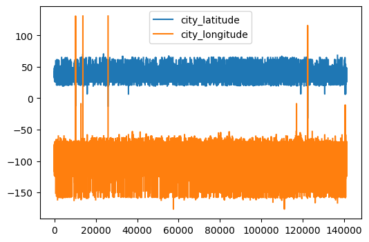

```python
# plot the graph of ufo_df, which only show two columns' values: city_latitude and city_longitude
ufo_df.plot()
plt.show()
```

```python
# checking if 2023 reports present
ufo_df[ufo_df["date_time"].str.contains("2023", na=False)]
```

|  | summary | country | city | state | date_time | shape | duration | stats | report_link | text | posted | city_latitude | city_longitude |
| --- | --- | --- | --- | --- | --- | --- | --- | --- | --- | --- | --- | --- | --- |

# Basic info about data: 36097 rows have missing values; 81358 missing value items

# The total number of rows with NaN values in at least one column

ufo_df.isnull().any(axis=1).sum()

```python
ufo_df[ufo_df.isnull().any(axis=1)]
```

|  | summary | country | city | state | date_time | shape | duration | stats | report_link | text | posted | city_latitude | city_longitude |
| --- | --- | --- | --- | --- | --- | --- | --- | --- | --- | --- | --- | --- | --- |
| 0 | MADAR Node 100 | USA | Mountlake Terrace | WA | 2019-06-23T18:53:00 | NaN | NaN | Occurred : 6/23/2019 18:53 (Entered as : 06/2... | http://www.nuforc.org/webreports/reports/147/S... | MADAR Node 100 | 2019-06-27T00:00:00 | 47.794100 | -122.306600 |
| 4 | Location: While traveling in a TGV, from Lille... | France | Douai (France) | NaN | 2019-06-07T20:00:00 | cigar | 5 minutes | Occurred : 6/7/2019 20:00 (Entered as : 06/07... | http://www.nuforc.org/webreports/reports/146/S... | Location: While traveling in a TGV, from Lill... | 2019-06-27T00:00:00 | NaN | NaN |
| 9 | MADAR Node 128 | USA | Helena | MT | 2019-07-01T14:48:00 | NaN | NaN | Occurred : 7/1/2019 14:48 (Entered as : 07/01... | http://www.nuforc.org/webreports/reports/147/S... | MADAR Node 128 | 2019-07-12T00:00:00 | 46.627429 | -112.012735 |
| 12 | While leaving a bar/restaurant situated on the... | USA | South Kingstown | WA | 2019-07-15T01:15:00 | unknown | 25 seconds | Occurred : 7/15/2019 01:15 (Entered as : 07/1... | http://www.nuforc.org/webreports/reports/147/S... | While leaving a bar/restaurant situated on the... | 2019-07-25T00:00:00 | NaN | NaN |
| 16 | ((HOAX??)) On Google earth, found underwater ... | USA | NaN | CA | NaN | NaN | NaN | Occurred : Reported: 7/24/2019 1:45:33 PM 13... | http://www.nuforc.org/webreports/reports/147/S... | I was on Google earth and found a underwater b... | NaN | NaN | NaN |
| ... | ... | ... | ... | ... | ... | ... | ... | ... | ... | ... | ... | ... | ... |
| 141252 | Saw bright moving objects in mid day sun, clea... | Mexico | Cabo San Lucas | NaN | 2021-12-15T11:30:00 | light | NaN | Occurred : 12/15/2021 11:30 (Entered as : 12/... | http://www.nuforc.org/webreports/reports/165/S... | Saw bright moving objects in mid day sun, clea... | 2021-12-19T00:00:00 | NaN | NaN |
| 141254 | Two lights spinning around each other . See vi... | Ireland | Cappagh | COUNTY WATERFORD | 2021-12-15T17:30:00 | light | >30 minutes | Occurred : 12/15/2021 17:30 (Entered as : 12/... | http://www.nuforc.org/webreports/reports/165/S... | Two lights spinning around each other . See vi... | 2021-12-19T00:00:00 | NaN | NaN |
| 141255 | I have video and digital pictures | USA | Bella Vista | NaN | 2021-12-15T19:00:00 | formation | 5 minutes | Occurred : 12/15/2021 19:00 (Entered as : 12/... | http://www.nuforc.org/webreports/reports/165/S... | I have video and digital pictures \n \n45000 f... | 2021-12-19T00:00:00 | NaN | NaN |
| 141256 | See craft every evening when I get out of work... | USA | Branford | CT | 2021-12-19T23:00:00 | circle | NaN | Occurred : 12/19/2021 23:00 (Entered as : 12/... | http://www.nuforc.org/webreports/reports/165/S... | See craft every evening when I get out of work... | 2021-12-19T00:00:00 | 41.277600 | -72.811500 |
| 141257 | MADAR Node 70 | USA | St Louis | MO | 2022-03-09T00:48:00 | NaN | NaN | Occurred : 3/9/2022 00:48 (Entered as : 03/09... | http://www.nuforc.org/webreports/reports/167/S... | MADAR Node 70 \n \n | 2022-04-22T00:00:00 | 38.626989 | -90.307029 |

36097 rows × 13 columns

```python
# The total number of NaN values
ufo_df.isnull().sum().sum()
```

```
81358
```

```python
# The columns that have NaN values: 11 columns out of 13
# Two columns have with values in all rows (no null values): stats and report_link
ufo_df.isnull().any()
```

```
summary            True
country            True
city               True
state              True
date_time          True
shape              True
duration           True
stats             False
report_link       False
text               True
posted             True
city_latitude      True
city_longitude     True
dtype: bool
```

```python
# The total rows of data with missing values in city column: 478
ufo_df[ufo_df["city"].isnull()].shape[0]
```

```
478
```

```python
# Display all columns with NaN values: 11 columns out of 13
ufo_df[ufo_df.columns[ufo_df.isna().any()]]
```

|  | summary | country | city | state | date_time | shape | duration | text | posted | city_latitude | city_longitude |
| --- | --- | --- | --- | --- | --- | --- | --- | --- | --- | --- | --- |
| 0 | MADAR Node 100 | USA | Mountlake Terrace | WA | 2019-06-23T18:53:00 | NaN | NaN | MADAR Node 100 | 2019-06-27T00:00:00 | 47.794100 | -122.306600 |
| 1 | Steady flashing object with three lights hover... | USA | Hamden | CT | 2019-06-23T20:00:00 | light | 5 hours | Steady flashing object with three lights hover... | 2019-06-27T00:00:00 | 41.373941 | -72.921325 |
| 2 | Group of several orange lights, seemingly circ... | USA | Charlottesville | VA | 2019-06-20T23:28:00 | circle | 15 seconds | Group of several orange lights, seemingly circ... | 2019-06-27T00:00:00 | 38.055968 | -78.494482 |
| 3 | Dropped in flashed a few times and shot off 5 ... | USA | Lincoln Park | MI | 2019-06-21T00:00:00 | light | 2 minutes | Dropped in flashed a few times and shot off 5 ... | 2019-06-27T00:00:00 | 42.238500 | -83.178300 |
| 4 | Location: While traveling in a TGV, from Lille... | France | Douai (France) | NaN | 2019-06-07T20:00:00 | cigar | 5 minutes | Location: While traveling in a TGV, from Lill... | 2019-06-27T00:00:00 | NaN | NaN |
| ... | ... | ... | ... | ... | ... | ... | ... | ... | ... | ... | ... |
| 141256 | See craft every evening when I get out of work... | USA | Branford | CT | 2021-12-19T23:00:00 | circle | NaN | See craft every evening when I get out of work... | 2021-12-19T00:00:00 | 41.277600 | -72.811500 |
| 141257 | MADAR Node 70 | USA | St Louis | MO | 2022-03-09T00:48:00 | NaN | NaN | MADAR Node 70 \n \n | 2022-04-22T00:00:00 | 38.626989 | -90.307029 |
| 141258 | A very small white light hovering above the cl... | USA | Batavia | IL | 2013-04-30T02:19:00 | circle | 45 seconds | A very small white light hovering above the cl... | 2013-05-15T00:00:00 | 41.847800 | -88.307500 |
| 141259 | I was young. You know what? It was pretty fuck... | USA | Liberty Lake | WA | 1995-07-21T09:00:00 | circle | 1/12 | I was young. You know what? It was pretty ((... | 2019-12-19T00:00:00 | 47.651700 | -117.083800 |
| 141260 | While driving at night, I watched two blue-gre... | USA | Fredericksburg | VA | 2019-12-24T18:30:00 | sphere | 4 seconds | While driving at night, I watched two blue-gre... | 2019-05-14T00:00:00 | 38.299511 | -77.500674 |

141261 rows × 11 columns

# Drop extraneous columns: report_link, posted

```python
# drop extraneous columns
ufo_df = ufo_df.drop(columns=["report_link","posted"])
ufo_df
```

|  | summary | country | city | state | date_time | shape | duration | stats | text | city_latitude | city_longitude |
| --- | --- | --- | --- | --- | --- | --- | --- | --- | --- | --- | --- |
| 0 | MADAR Node 100 | USA | Mountlake Terrace | WA | 2019-06-23T18:53:00 | NaN | NaN | Occurred : 6/23/2019 18:53 (Entered as : 06/2... | MADAR Node 100 | 47.794100 | -122.306600 |
| 1 | Steady flashing object with three lights hover... | USA | Hamden | CT | 2019-06-23T20:00:00 | light | 5 hours | Occurred : 6/23/2019 20:00 (Entered as : 6/23... | Steady flashing object with three lights hover... | 41.373941 | -72.921325 |
| 2 | Group of several orange lights, seemingly circ... | USA | Charlottesville | VA | 2019-06-20T23:28:00 | circle | 15 seconds | Occurred : 6/20/2019 23:28 (Entered as : 06/2... | Group of several orange lights, seemingly circ... | 38.055968 | -78.494482 |
| 3 | Dropped in flashed a few times and shot off 5 ... | USA | Lincoln Park | MI | 2019-06-21T00:00:00 | light | 2 minutes | Occurred : 6/21/2019 00:00 (Entered as : 06/2... | Dropped in flashed a few times and shot off 5 ... | 42.238500 | -83.178300 |
| 4 | Location: While traveling in a TGV, from Lille... | France | Douai (France) | NaN | 2019-06-07T20:00:00 | cigar | 5 minutes | Occurred : 6/7/2019 20:00 (Entered as : 06/07... | Location: While traveling in a TGV, from Lill... | NaN | NaN |
| ... | ... | ... | ... | ... | ... | ... | ... | ... | ... | ... | ... |
| 141256 | See craft every evening when I get out of work... | USA | Branford | CT | 2021-12-19T23:00:00 | circle | NaN | Occurred : 12/19/2021 23:00 (Entered as : 12/... | See craft every evening when I get out of work... | 41.277600 | -72.811500 |
| 141257 | MADAR Node 70 | USA | St Louis | MO | 2022-03-09T00:48:00 | NaN | NaN | Occurred : 3/9/2022 00:48 (Entered as : 03/09... | MADAR Node 70 \n \n | 38.626989 | -90.307029 |
| 141258 | A very small white light hovering above the cl... | USA | Batavia | IL | 2013-04-30T02:19:00 | circle | 45 seconds | Occurred : 4/30/2013 02:19 (Entered as : 04/3... | A very small white light hovering above the cl... | 41.847800 | -88.307500 |
| 141259 | I was young. You know what? It was pretty fuck... | USA | Liberty Lake | WA | 1995-07-21T09:00:00 | circle | 1/12 | Occurred : 7/21/1995 09:00 (Entered as : 07/2... | I was young. You know what? It was pretty ((... | 47.651700 | -117.083800 |
| 141260 | While driving at night, I watched two blue-gre... | USA | Fredericksburg | VA | 2019-12-24T18:30:00 | sphere | 4 seconds | Occurred : 12/24/2019 18:30 (Entered as : 012... | While driving at night, I watched two blue-gre... | 38.299511 | -77.500674 |

141261 rows × 11 columns

# Drop the rows with missing values in all city, state, country columns: 146 rows

**Rationale:** Location data needed/required to be used in my modeling. If there is no location data entered for the row, then it renders that row not viable for project's purposes.

```python
# Make a mask with the missing values for all three location columns
mask = ufo_df[["city", "state", "country"]].isnull().all(axis=1)

# Count the number of missing values in the mask
total = mask.sum()
print("Total of", total, "rows of missing values in all three columns of city, state, and country.")
```

```
Total of 146 rows of missing values in all three columns of city, state, and country.
```

```python
# Drop the rows with missing values in all three columns: removal of 146 rows
ufo_df = ufo_df.dropna(subset=["city", "state", "country"], how="all")
```

```python
# Check to see if these rows have been deleted
mask = ufo_df[["city", "state", "country"]].isnull().all(axis=1)

# Get the entire row of data for those rows
ufo_df[mask]
```

|  | summary | country | city | state | date_time | shape | duration | stats | text | city_latitude | city_longitude |
| --- | --- | --- | --- | --- | --- | --- | --- | --- | --- | --- | --- |

## ufo_df now has 141115 viable records

```python
ufo_df.shape[0]
```

```
141115
```

# Fix the city column for errors

- Remove from the city column of ufo_df "," characters and text after the comma
- Removes '(" or ")" characters and any text in them
- Remove spaces before and after the city values
- Remove ? character

```python
# displays number of rows with "," character in the city column
ufo_df[ufo_df["city"].str.contains(",", na=False)].shape[0]
```

```
829
```

```python
# fix_city repairs city column for specific errors
def fix_city(df):
    # remove the comma character and all text after it (errors in rows 789, 869, etc; total of 829 rows with this error)
    df["city"] = df["city"].str.split(",").str[0]
    # removes '(" or ")" characters and any text in them
    df.loc[:, "city"] = df["city"].str.replace(r"\(.*\)", "", regex=True)
    # remove spaces before and after the city values
    df["city"] = df["city"].str.strip()
    # remove ? character (error in row 805)
    df["city"] = df["city"].str.strip("?")
    # change to title case
    df["city"] = df["city"].str.title()

fix_city(ufo_df)
```

# May need to remove

## Get the latitude and longitude for analysis later

```python
lat_long_df = ufo_df[["city", "city_latitude", "city_longitude"]]
lat_long_df
```

|  | city | city_latitude | city_longitude |
| --- | --- | --- | --- |
| 0 | Mountlake Terrace | 47.794100 | -122.306600 |
| 1 | Hamden | 41.373941 | -72.921325 |
| 2 | Charlottesville | 38.055968 | -78.494482 |
| 3 | Lincoln Park | 42.238500 | -83.178300 |
| 4 | Douai | NaN | NaN |
| ... | ... | ... | ... |
| 141256 | Branford | 41.277600 | -72.811500 |
| 141257 | St Louis | 38.626989 | -90.307029 |
| 141258 | Batavia | 41.847800 | -88.307500 |
| 141259 | Liberty Lake | 47.651700 | -117.083800 |
| 141260 | Fredericksburg | 38.299511 | -77.500674 |

141115 rows × 3 columns

# Fix state column for errors

```python
# fix_state() takes a dataframe as an argument, has embedded helper function that applies
#    corrections to the state and country columns (for errors in row 136716, 137237, 137247, 137458 and on)
def fix_state(df):
  def fix_state_helper(row):
    # Get the state and country values from the row
    state = str(row["state"])
    country = row["country"]
    # Check if the state has 4 or more characters
    if len(str(state)) >= 4:
      # Check if the state is Quebec and the country is Canada
      if state == "QUEBEC" and country == "Canada":
        # Reassign it to QC
        return "QC"
      # Check if the state is Ontario and the country is Canada
      elif state == "ONTARIO" and country == "Canada":
        # Reassign it to ON
        return "ON"
      # Check if the state is Ontario and the country is USA
      elif state == "ONTARIO" and country == "USA":
        # Reassign it to the title case of the state (not all caps)
        return state.title()
      else:
        # Return the original state
        return state
    else:
      # Return the original state
      return state
  # Apply the check_state_helper function to the dataframe and assign the result back to the state column
  df["state"] = df.apply(fix_state_helper, axis=1)


# Call the fix_state function
fix_state(ufo_df)
```

# Change the values of the country column to titlecase lowercase

```python
# fix_title_case() changes string s to title case
def fix_title_case(string):
    string = str(string)
    # returns a string in which each word's first letter has been changed to uppercase
    return re.sub(r"[A-Za-z]+('[A-Za-z]+)?", lambda word: word.group(0).capitalize(), string)

ufo_df["country"] = ufo_df["country"].apply(fix_title_case)
```

# Fix state and country column for specific errors

```python
# check_country() takes a dataframe as an argument and repairs state and/or country columns for errors/non-standardized formatting
# NOTE: check_country takes about 5 minutes to run
def check_country(df):
  def check_country_helper(row):
    # get the state, country, and city values from the row
    state = row["state"]
    country = row["country"]
    city = row["city"]

    # check if the country is Colorado Springs (error in row 131202)
    if country == "Colorado Springs":
      # Reassign country to USA
      return pd.Series({"state": state, "country": "USA"})
    # check if the country is Ireland (for 171+ rows)
    elif country == "Ireland" or country == "Dublin Ireland" or country == "Northern Ireland" or country == "Republic Of Ireland":
      # reassign country to United Kingdom and state to Ireland
      return pd.Series({"state": "Ireland", "country": "United Kingdom"})
    # check if the country is Scotland (for 4 rows)
    elif country == "North Wales" or country == "Uk/Wales":
      # reassign country to United Kingdom and state to Scotland
      return pd.Series({"state": "Wales", "country": "United Kingdom"})
       # check if the country is Scotland (for 4 rows)
    elif country == "Scotland":
      # reassign country to United Kingdom and state to Scotland
      return pd.Series({"state": "Scotland", "country": "United Kingdom"})
    elif country == "United Kingdom":
      if (city == "Essex"):
          # assign state to Essex so map will display correctly
          return pd.Series({"state": "Essex", "country": country})
    elif country == "Unknown":
      # check if this city is in a US state so map will display correctly
      if (city == "Essex") and ((state == "CA")|(state == "CT")|(state == "MD")|(state == "MT")|(state == "NC")|(state == "VT")):
          # assign country to "USA"
          return pd.Series({"state": state, "country": "USA"})
    # check if the country is "China Also?"" (1 row)
    elif country == "China Also?":
      if (city == "New Orleans"):
          # reassign country to USA
          return pd.Series({"state": state, "country": "USA"})
    # check if the country is Russia (Former Ukraine) (1 row)
    elif country == "Russia (Former Ukraine)":
      if (city == "Mariupol"):
          # reassign country to Ukraine
          return pd.Series({"state": state, "country": "Ukraine"})
    # check if the country is Yes (4 errors)
    elif country == "Yes":
      if (city == "Belfast"):
          # reassign country to United Kingdom and state to Ireland
          return pd.Series({"state": "Ireland", "country": "United Kingdom"})
      elif (city == "Cebu"):
          # reassign country to Philippines
          return pd.Series({"state": state, "country": "Philippines"})
      else:
         # reassign country to Unknown
          return pd.Series({"state": state, "country": "Unknown"})
    else:
      # return the original state and country values
      return pd.Series({"state": state, "country": country})

  # apply the check_country_helper function to the dataframe and assign the result back to the state and country columns
  df[["state", "country"]] = df.apply(check_country_helper, axis=1)

check_country(ufo_df)
```

```python
# fix_country repairs country column for specific errors seen in the dataframe
def fix_country(df):
    # remove spaces before and after the country values (error in row 1057)
    df["country"] = df["country"].str.strip()

    # replace "Bahamas/Usa" with "Bahamas" in the country column (1 error)
    df["country"] = df["country"].replace("Bahamas/Usa", "Bahamas")

    # replace "Caribbean" with "Caribbean Sea" in the country column (1 error)
    df["country"] = df["country"].replace("Caribbean", "Caribbean Sea")

    # replace "Grand Cayman" with "Grand Cayman Island" in the country column (3 errors)
    df["country"] = df["country"].replace("Grand Cayman", "Grand Cayman Island")

    # replace "Guatamala" with "Guatemala" in the country column (1 error)
    df["country"] = df["country"].replace("Guatamala", "Guatemala")

    # replace "Gulf Of Mexico / Florida Straits" with "Gulf Of Mexico" in the country column (1 error)
    df["country"] = df["country"].replace("Gulf Of Mexico / Florida Straits", "Gulf Of Mexico")

    # replace "Guyana, South America" with "Guyana" in the country column (1 error)
    df["country"] = df["country"].replace("Guyana, South America", "Guyana")

    # replace "Hong Kong S.A.R." with "Hong Kong" in the country column (1 error)
    df["country"] = df["country"].replace("Hong Kong S.A.R.", "Hong Kong")
    # replace "Hong Kong Sar" with "Hong Kong" in the country column (1 error)
    df["country"] = df["country"].replace("Hong Kong Sar", "Hong Kong")

    # replace "India (South- East)" with "India" in the country column (1 error)
    df["country"] = df["country"].replace("India (South- East)", "India")

    # replace "In Orbit" with "In Orbit (In Space)" in the country column (13 errors)
    df["country"] = df["country"].replace("In Orbit", "In Orbit (In Space)")
    # replace "In Orbit In Space" with "In Orbit (In Space)" in the country column (1 error)
    df["country"] = df["country"].replace("In Orbit In Space", "In Orbit (In Space)")
    # replace "In Orbit (Space)" with "In Orbit (In Space)" in the country column (1 error)
    df["country"] = df["country"].replace("In Orbit (Space)", "In Orbit (In Space)")

    # replace "Isle Of Man, Great Britain" with "Isle Of Man" in the country column (1 error)
    df["country"] = df["country"].replace("Isle Of Man, Great Britain", "Isle Of Man")

    # replace "Kazakstan" with "Kazakhstan" in the country column (1 error)
    df["country"] = df["country"].replace("Kazakstan", "Kazakhstan")

    # replace "Kenya (East Africa)" with "Kenya" in the country column (1 error)
    df["country"] = df["country"].replace("Kenya (East Africa)", "Kenya")

    # replace "Korea (South)" with "South Korea" in the country column (1 error)
    df["country"] = df["country"].replace("Korea (South)", "South Korea")
    # replace "Korea South" with "South Korea" in the country column (1 error)
    df["country"] = df["country"].replace("Korea South", "South Korea")
    # replace "Republic Of Korea" with "South Korea" in the country column (1 error)
    df["country"] = df["country"].replace("Republic Of Korea", "South Korea")

    # replace "Kosova" with "Kosovo" in the country column (1 error)
    df["country"] = df["country"].replace("Kosova", "Kosovo")

    # replace "Lebanon (Middle East)" with "Lebanon" in the country column (1 error)
    df["country"] = df["country"].replace("Lebanon (Middle East)", "Lebanon")

    # replace "Luxembourg" with "Luxemburg" (German-preferred spelling) in the country column (1 error)
    df["country"] = df["country"].replace("Luxembourg", "Luxemburg")

    # replace "Mediterrainian Sea" with "Mediterranean Sea" in the country column (1 error)
    df["country"] = df["country"].replace("Mediterrainian Sea", "Mediterranean Sea")
    # replace "Mediterranean Sea." with "Mediterranean Sea" in the country column (1 error)
    df["country"] = df["country"].replace("Mediterranean Sea.", "Mediterranean Sea")

    # replace "Myanmar (Burma)" with "Myanmar" (1 error)
    df["country"] = df["country"].replace("Myanmar (Burma)", "Myanmar")

    # replace "Netherlands The" with "Netherlands" in the country column (1 error)
    df["country"] = df["country"].replace("Netherlands The", "Netherlands")

    # replace "Netherland Antilles" with "Netherlands Antilles" in the country column (1 error)
    df["country"] = df["country"].replace("Netherland Antilles", "Netherlands Antilles")

    # replace "Nigeria 🇳🇬" with "Nigeria" in the country column (1 error)
    df["country"] = df["country"].replace("Nigeria 🇳🇬", "Nigeria")

    # replace "Japan (Okinawa)" with "Okinawa" in the country column (1 error)
    df["country"] = df["country"].replace("Japan (Okinawa)", "Okinawa")
    # replace "Okinawa Japan" with "Okinawa" in the country column (1 error)
    df["country"] = df["country"].replace("Okinawa Japan", "Okinawa")

    # replace "Panama Canal Zone" with "Panama Canal" in the country column (1 error)
    df["country"] = df["country"].replace("Panama Canal Zone", "Panama Canal")

    # replace "Perú" with "Peru" in the country column (1 error)
    df["country"] = df["country"].replace("Perú", "Peru")

    # replace "Puerto Rico Commonwealth" with "Puerto Rico" in the country column (1 error)
    df["country"] = df["country"].replace("Puerto Rico Commonwealth", "Puerto Rico")
    # replace "Puerto Rico Usa" with "Puerto Rico" in the country column (1 error)
    df["country"] = df["country"].replace("Puerto Rico Usa", "Puerto Rico")

    # replace "Russia (Ussr)" with "Russia" in the country column (1 error)
    df["country"] = df["country"].replace("Russia (Ussr)", "Russia")
    # replace "Russian Federation" with "Russia" in the country column (1 error)
    df["country"] = df["country"].replace("Russian Federation", "Russia")

    # replace "Slovak Republic" with "Slovakia" in the country column (1 error)
    df["country"] = df["country"].replace("Slovak Republic", "Slovakia")

    # replace "Republic Of South Africa" with "South Africa" in the country column (1 error)
    df["country"] = df["country"].replace("Republic Of South Africa", "South Africa")
    # replace "South  Africa" with "South Africa" in the country column (1 error)
    df["country"] = df["country"].replace("South  Africa", "South Africa")
    # replace "South-Africa" with "South Africa" in the country column (1 error)
    df["country"] = df["country"].replace("South-Africa", "South Africa")
```

```python
    # replace "Srilanka" with "Sri Lanka" in the country column (1 error)
    df["country"] = df["country"].replace("Srilanka", "Sri Lanka")
    # replace "Srui Lanka" with "Sri Lanka" in the country column (1 error)
    df["country"] = df["country"].replace("Srui Lanka", "Sri Lanka")

    # replace "Surinam" with "Suriname" in the country column (1 error)
    df["country"] = df["country"].replace("Surinam", "Suriname")

    # replace "Swizterland" with "Switzerland" in the country column (1 error)
    df["country"] = df["country"].replace("Swizterland", "Switzerland")

    # replace "Tenerife, Spain" with "Tenerife" in the country column (1 error)
    df["country"] = df["country"].replace("Tenerife, Spain", "Tenerife")

    # replace "Trinidad And Tobago" with "Trinidad & Tobago" in the country column (1 error)
    df["country"] = df["country"].replace("Trinidad And Tobago", "Trinidad & Tobago")
    # replace "Trinidad/Tobago" with "Trinidad & Tobago" in the country column (1 error)
    df["country"] = df["country"].replace("Trinidad/Tobago", "Trinidad & Tobago")

    # replace "Caicos Islands" with "Turks & Caicos Islands" in the country column (1 error)
    df["country"] = df["country"].replace("Caicos Islands", "Turks & Caicos Islands")
    # replace "Turks & Caicos" with "Turks & Caicos Islands" in the country column (1 error)
    df["country"] = df["country"].replace("Turks & Caicos", "Turks & Caicos Islands")
    # replace "Turks And Caicos Islands" with "Turks & Caicos Islands" in the country column (3 errors)
    df["country"] = df["country"].replace("Turks And Caicos Islands", "Turks & Caicos Islands")

    # replace "TüRkiye" with "Turkey" in the country column (1 error)
    df["country"] = df["country"].replace("TüRkiye", "Turkey")

    # replace "United Arab Emirates" with "UAE" in the country column (29 error)
    df["country"] = df["country"].replace("United Arab Emirates", "UAE")
    # replace "United Arad Emirates" with "UAE" in the country column (1 error)
    df["country"] = df["country"].replace("United Arad Emirates", "UAE")
    # replace "Uae" with "UAE" in the country column (1 error)
    df["country"] = df["country"].replace("Uae", "UAE")

    # replace "Us And Canada Border" with "USA & Canada Border" in the country column (1 error)
    df["country"] = df["country"].replace("Us And Canada Border", "USA & Canada Border")
    # replace "Usa & Canada" with "USA & Canada Border" in the country column (1 error)
    df["country"] = df["country"].replace("Usa & Canada", "USA & Canada Border")
    # replace "Usa/Canadian Waters" with "USA & Canada Border" in the country column (1 error)
    df["country"] = df["country"].replace("Usa/Canadian Waters", "USA & Canada Waters")

    # replace "United States" with "USA" in the country column (error in row 137081)
    df["country"] = df["country"].replace("United States", "USA")
    # replace "Untied States Of America" with "USA" in the country column (error in row 137081)
    df["country"] = df["country"].replace("Untied States Of America", "USA")
    # replace "U.S.A." with "USA" in the country column (1 error)
    df["country"] = df["country"].replace("U.S.A.", "USA")
    # replace "usa" with "Usa" in the country column (errors in rows 95200, 132558)
    df["country"] = df["country"].replace("Usa", "USA")
    # replace "Usav" with "Usausa" in the country column (1 error)
    df["country"] = df["country"].replace("Usav", "USA")
    # replace "usa" with "Usausa" in the country column (1 error)
    df["country"] = df["country"].replace("Usausa", "USA")

    # replace "Great Britain" with "United Kingdom" (error in row 66854)
    df["country"] = df["country"].replace("Great Britain", "United Kingdom")
    # replace "Uk/England" with "United Kingdom" (errors in rows 138737, 139079, 139448)
    df["country"] = df["country"].replace("Uk/England", "United Kingdom")
    # replace several designations of Virgin Islands with "Virgin Islands (USA) or (UK)"
    df["country"] = df["country"].replace("Us Virgin Islands", "Virgin Islands (USA)")
    df["country"] = df["country"].replace("U. S. Virgin Islands", "Virgin Islands (USA)")
    df["country"] = df["country"].replace("U.S. Virgin Islands", "Virgin Islands (USA)")
    df["country"] = df["country"].replace("Virgin Islands (Us)","Virgin Islands (USA)")
    df["country"] = df["country"].replace("Virgin Islands (U. S.)","Virgin Islands (USA)")
    df["country"] = df["country"].replace("Virgin Islands (U.S.)","Virgin Islands (USA)")
    df["country"] = df["country"].replace("Usvi","Virgin Islands (USA)")
    df["country"] = df["country"].replace("Ukvi","Virgin Islands (UK)")
    df["country"] = df["country"].replace("UK Virgin Islands", "Virgin Islands (UK)")
    df["country"] = df["country"].replace("British Virgin Islands", "Virgin Islands (UK)")

    # replace "Viet Nam" with "Vietnam" (25 errors)
    df["country"] = df["country"].replace("Viet Nam", "Vietnam")

    # replace "Nan" with "Unknown" (1 error)
    df["country"] = df["country"].replace("Nan", "Unknown")
    # replace "No" with "Unknown" (1 error)
    df["country"] = df["country"].replace("No", "Unknown")
    # replace "Non Applicable" with "Unknown" (1 error)
    df["country"] = df["country"].replace("Non Applicable", "Unknown")
    # replace "None" with "Unknown" (1 error)
    df["country"] = df["country"].replace("None", "Unknown")
    # replace "Yup" with "Unknown" (1 error)
    df["country"] = df["country"].replace("Yup", "Unknown")

    # replace city = "United States" to None (error in row 41194)
    if (df["city"] == "United States").any() and (df["country"] == "USA").any():
        df["city"] = df["city"].replace("United States", "")

fix_country(ufo_df)
```

```python
# Remove later for testing
#ufo_df.loc[ufo_df["city"] == "Essex"]
```

```python
# check_us_state() takes a dataframe as an argument, checks whether country == "U" AND
#     state is a US state, and if so, assigns country = "USA"
def check_us_state(df):
    # make a copy the original dataframe so we don't alter actual df's other columns other than the country column
    df_copy = df.copy()
    # check the dataframe for rows with country == "U"
    tmp_df = df_copy[df_copy["country"] == "U"]

    # define a function that returns True if the string is a US state, False otherwise
    def is_us_state(s):
        return bool(us.states.lookup(s))

    # apply the function to the state column and store the result in a new column called 'is_state'
    tmp_df["is_state"] = tmp_df["state"].apply(is_us_state)

    # assign "USA" to the country column where is_state is True
    tmp_df.loc[tmp_df["is_state"], 'country'] = "USA"

    # drop the is_state column
    tmp_df = tmp_df.drop("is_state", axis=1)

    # update the original dataframe with the filtered dataframe
    df_copy.update(tmp_df)

    # return the updated dataframe
    return df_copy

ufo_df = check_us_state(ufo_df)
```

```python
### Remove later ###
# get list of total sightings by country/territories
#sightings_test = ufo_df.groupby("country").size() # group by country
#count = sightings_test.shape[0] # get the count of each country group
#print("count: ", count, " countries/territories")

# iterate over the countries in sightings_test
#for index, value in sightings_test.items():
#    print(index, "\t", value)
```

## Function definitions of print functions to display lists

```python
# print_list prints the counter series argument in a list form starting with 1
def print_list(statement, colname, colname2, counter):
    print(statement, "\n  ", colname, "\t\t      ", colname2)
    i = 1
    while i <= len(counter):
        row = counter.iloc[i-1]
       # checks whether i > 9 and the length of colname > 19 chars to display with less tab space
        if (i > 9) and (len(row[colname]) > 19):
            print(f"{i}. {row[colname]}\t{row[colname2]}")
        else:
            print(f"{i}. {row[colname]}\t\t{row[colname2]}")
        i += 1

# print_med_list prints the counter series argument in a medium list form starting with 1
def print_med_list(statement, colname, colname2, counter):
    print(statement, "\n  ", colname, "      ", colname2)
    i = 1
    while i <= len(counter):
        row = counter.iloc[i-1]
        if i < 10:
            print(f"{i}. {row[colname]}\t\t{row[colname2]}")
        else:
            print(f"{i}. {row[colname]}\t{row[colname2]}")
        i += 1

# print_sm_list prints the counter series argument in a small list form starting with 1
def print_sm_list(statement, colname, colname2, counter):
    print(statement, "\n  ", colname, "      ", colname2)
    i = 1
    while i <= len(counter):
        row = counter.iloc[i-1]
        print(f"{i}. {row[colname]}\t\t{row[colname2]}")
        i += 1

# print_list_no_num prints the counter series argument in a list form without numbers
def print_list_no_num(statement, colname, colname2, counter):
    print(statement, colname, " ", colname2)
    i = 1
    while i <= len(counter):
        row = counter.iloc[i-1]
        print(f" {row[colname]}\t{row[colname2]}")
        i += 1

# print_longlist_no_num prints the counter series argument in a list form without numbers
def print_longlist_no_num(statement, colname, colname2, counter):
    print(statement, colname, "\t       ", colname2)
    i = 1
    while i <= len(counter):
        row = counter.iloc[i-1]
        print(f" {row[colname]}\t{row[colname2]}")
        i += 1
```

## Supplemental Question: Compare Years with the Counts of UFO Sightings (WITHOUT hoax filter) -- For analysis later

```python
# Supplemental Question: Compare Years with the Counts of UFO Sightings (WITHOUT hoax filter)
### For Analysis of Supplemental Questions secton below  ###
# extract the year from the date_time column
compare_df = ufo_df.copy()  # Need to make copy of ufo_df of possibility of altering the working dataframe
compare_df["year"] = pd.DatetimeIndex(compare_df["date_time"]).year
compare_df2 = ufo_df.copy()
compare_df2["year"] = pd.DatetimeIndex(compare_df2["date_time"]).year

# create a list of years for comparison
yr_list = [1762, 1780, 1800, 1810, 1820, 1850, 1870, 1880, 1900, 1910, 1920, 1925, 1930, 1935, 1940, 1945, 1950, 1955, 1960, 1965, 1970, 1975, 1980, 1985, 1990, 1995, 2000, 2005, 2010, 2011, 2012, 2013, 2014, 2015, 2016, 2017, 2018, 2019, 2020, 2021, 2022]
recent_yr_list = [1960,1970,1971,1972,1973,1974,1975,1976,1977,1978,1979,1980,1981,1982,1983,1984,1985,1987,1988,1989,1990,1991,1992,1993,1994,1995,1996,1997,1998,1999,2000,2001,2002,2003,2004,2005,2006,2007,2008,2009,2010,2011,2012,2013,2014,2015,2016,2017,2018,2019,2020,2021,2022]

# filter the dataframe by the given years
compare_df = compare_df.loc[compare_df["year"].isin(yr_list)]
compare_df2 = compare_df2.loc[compare_df2["year"].isin(recent_yr_list)]

# group by year and count sightings
yrs_comp_no_fil = compare_df.groupby("year").size()
recent_yrs_comp_no_fil = compare_df2.groupby("year").size()

# reset index to count
yrs_comp_no_fil = yrs_comp_no_fil.reset_index(name="count")
recent_yrs_comp_no_fil = recent_yrs_comp_no_fil.reset_index(name="count")

#print("Year and Counts of UFO Sightings (no hoax filter)\n", yrs_comp_no_fil.head(7).astype(int).to_string(index=False))
#print("\nRecent Year and Counts of UFO Sightings (no hoax filter)\n", recent_yrs_comp_no_fil.tail(7).astype(int).to_string(index=False))
```

## Supplemental Question: Top 10 Cities with Highest Counts of UFO Sightings WITHOUT hoax filter -- For analysis later

```python
# Supplemental Question:  Top 10 Locations with Highest Counts of UFO Sightings WITHOUT hoax filter
# Get the top 10 locations with UFO sightings
compare_df = ufo_df.copy()
# group by location and count sightings
sightings_no_fil = compare_df.groupby(["city"]).size()
sightings_st_no_fil = compare_df.groupby(["state"]).size()
sightings_ctry_no_fil = compare_df.groupby(["country"]).size()

# sort by count in descending order
sightings_no_fil = sightings_no_fil.sort_values(ascending=False)
sightings_st_no_fil = sightings_st_no_fil.sort_values(ascending=False)
sightings_ctry_no_fil = sightings_ctry_no_fil.sort_values(ascending=False)

# select the first 10 rows
sightings_no_fil = sightings_no_fil.head(10)
sightings_st_no_fil = sightings_st_no_fil.head(10)
sightings_ctry_no_fil = sightings_ctry_no_fil.head(10)

# reset index to get a dataframe
sightings_no_fil = sightings_no_fil.reset_index(name='count')
sightings_st_no_fil = sightings_st_no_fil.reset_index(name='count')
sightings_ctry_no_fil = sightings_ctry_no_fil.reset_index(name='count')

# add 1 to the new index to make list start at 1
sightings_no_fil.index = sightings_no_fil.index + 1
sightings_st_no_fil.index = sightings_st_no_fil.index + 1
sightings_ctry_no_fil.index = sightings_ctry_no_fil.index + 1

#print("Top Cities of UFO Sightings (no hoax filter)\n", sightings_no_fil)
#print("\nTop States of UFO Sightings (no hoax filter)\n", sightings_st_no_fil)
#print("\nTop Countries of UFO Sightings (no hoax filter)\n", sightings_ctry_no_fil)
```

## Supplemental Question: Top 10 US Cities and States of Highest Counts of UFO Sightings WITHOUT hoax filter -- For comparison later

```python
# Supplemental Question:  Top 10 US Locations and States of Highest Counts of UFO Sightings WITHOUT hoax filter
# Get the top 10 US locations with UFO sightings
compare_df = ufo_df.copy()  # Need to make copy of ufo_df because this block may alter the actual ufo_df dataframe
# filter the dataframe by country not equal to USA
compare_df = compare_df.loc[compare_df["country"] == "USA"]

# group by location and count sightings
sightings_us_no_fil = compare_df.groupby(["city"]).size()
sightings_us_st_no_fil = compare_df.groupby(["state"]).size()

# sort by count in descending order
sightings_us_no_fil = sightings_us_no_fil.sort_values(ascending=False)
sightings_us_st_no_fil = sightings_us_st_no_fil.sort_values(ascending=False)

# select the first 10 rows
sightings_us_no_fil = sightings_us_no_fil.head(10)
sightings_us_st_no_fil = sightings_us_st_no_fil.head(10)

# reset index to get a dataframe
sightings_us_no_fil = sightings_us_no_fil.reset_index(name='count')
sightings_us_st_no_fil = sightings_us_st_no_fil.reset_index(name='count')

# add 1 to the new index to make list start at 1
sightings_us_no_fil.index = sightings_us_no_fil.index + 1
sightings_us_st_no_fil.index = sightings_us_st_no_fil.index + 1

#print("Top US Cities with UFO Sightings without hoax filter\n", sightings_us_no_fil)
#print("\nTop US States with UFO Sightings without hoax filter\n", sightings_us_st_no_fil)
```

# Formulate a basic filter for hoaxes and fakes by filtering suspected words from the summary and text columns

```python
# Convert the text within the summary and text columns to lowercase
ufo_df["summary"].str.lower()
ufo_df["text"].str.lower()

# Print total count of rows with the words "hoax", "fake", "joke", or "prank" in either column
print(ufo_df.loc[ufo_df["summary"].str.lower().str.contains("hoax|fake|joke|prank", na=False)
        | ufo_df["text"].str.lower().str.contains("hoax|fake|joke|prank", na=False)].shape[0])
```

```
3241
```

## Check out the individual suspect summary and text columns for hoax reports

### Note: For the following code blocks, check out suspect words in the summary and text columns and count of rows with suspect words

```python
## Count of Rows with the words "hoax", "fake", "joke", or "prank" in summary and text columns: 3241
# Extract the rows that contain those words in either column
ufo_df.loc[ufo_df["summary"].str.lower().str.contains("hoax|fake|joke|prank")
       | ufo_df["text"].str.lower().str.contains("hoax|fake|joke|prank")]
```

|  | summary | country | city | state | date_time | shape | duration | stats | text | city_latitude | city_longitude |
| --- | --- | --- | --- | --- | --- | --- | --- | --- | --- | --- | --- |
| 16 | ((HOAX??)) On Google earth, found underwater ... | USA | NaN | CA | NaN | NaN | NaN | Occurred : Reported: 7/24/2019 1:45:33 PM 13... | I was on Google earth and found a underwater b... | NaN | NaN |
| 45 | Low flying huge disc spotted in Indianapolis, ... | USA | Indianapolis | IN | NaN | disk | 5 minutes | Occurred : 6/15/1963 22:00 (Entered as : 06/1... | Low flying huge disc spotted in Indianapolis, ... | 39.804642 | -86.137737 |
| 82 | Orange craft moving silently and fading in and... | USA | Westborough | MA | 2000-03-31T20:30:00 | triangle | 30-45 seconds | Occurred : 3/31/2000 20:30 (Entered as : 0331... | Orange craft moving silently and fading in and... | 42.264700 | -71.617500 |
| 229 | Orangy/Amber orbs of light up close | USA | Rachel | NV | 2019-09-20T23:56:00 | sphere | 5 - 10 min. | Occurred : 9/20/2019 23:56 (Entered as : 09/2... | Orangy/Amber orbs of light up close \n \nMe an... | NaN | NaN |
| 284 | ((HOAX??)) Me and my friend were out walking ... | USA | Marengo | IN | 2019-10-04T00:00:00 | light | NaN | Occurred : 10/4/2019 (Entered as : 11/15/19)... | Me and my friend were out walking the hunting ... | 38.377600 | -86.357200 |
| ... | ... | ... | ... | ... | ... | ... | ... | ... | ... | ... | ... |
| 140936 | ((HOAX??)) Looked to be changing attitude | USA | Weatogue | CT | 2022-05-01T14:43:00 | unknown | 3 minutes | Occurred : 5/1/2022 14:43 (Entered as : 05/01... | Looked to be changing attitude \n \nPossible D... | 41.904467 | -72.993000 |
| 141119 | IN DANGER Actual footage of UFO's and Alien on... | USA | Lumberton | MS | 2022-04-19T23:56:00 | triangle | All the time | Occurred : 4/19/2022 23:56 (Entered as : 04/1... | IN DANGER Actual footage of UFO's and Alien on... | 30.997900 | -89.454700 |
| 141124 | ((HOAX)) alien | USA | Daytona Beach | FL | 2022-04-21T15:30:00 | triangle | 5 seconds | Occurred : 4/21/2022 15:30 (Entered as : 04/2... | My Girlfriend doesnt love me and she thinks im... | 29.201564 | -81.043778 |
| 141174 | ((HOAX)) 11111 | Unknown | Grayson | nan | 2022-05-09T17:10:00 | NaN | Spam | Occurred : 5/9/2022 17:10 (Entered as : 05/09... | 11111 \n \nSpam | NaN | NaN |
| 141258 | A very small white light hovering above the cl... | USA | Batavia | IL | 2013-04-30T02:19:00 | circle | 45 seconds | Occurred : 4/30/2013 02:19 (Entered as : 04/3... | A very small white light hovering above the cl... | 41.847800 | -88.307500 |

3241 rows × 11 columns

```python
# Have a total count of rows with suspect words
ufo_df.loc[ufo_df["summary"].str.lower().str.contains("hoax|fake|joke|prank", na=False)].shape[0]
```

```
1490
```

```python
# Have a total count of rows with "suspect words"
ufo_df.loc[ufo_df["text"].str.lower().str.contains("hoax|fake|joke|prank", na=False)].shape[0]
```

```
2459
```

```python
ufo_df.loc[ufo_df["summary"].str.lower().str.contains("hoax|fake", na=False)].shape[0]
```

```
1458
```

```python
ufo_df.loc[ufo_df["text"].str.lower().str.contains("hoax|fake", na=False)].shape[0]
```

```
1552
```

```python
# Extract the rows that contain "hoax" that are found only in summary column
ufo_df.loc[ufo_df["summary"].str.lower().str.contains("hoax|fake", na=False)]
```

|  | summary | country | city | state | date_time | shape | duration | stats | text | city_latitude | city_longitude |
| --- | --- | --- | --- | --- | --- | --- | --- | --- | --- | --- | --- |
| 16 | ((HOAX??)) On Google earth, found underwater ... | USA | NaN | CA | NaN | NaN | NaN | Occurred : Reported: 7/24/2019 1:45:33 PM 13... | I was on Google earth and found a underwater b... | NaN | NaN |
| 284 | ((HOAX??)) Me and my friend were out walking ... | USA | Marengo | IN | 2019-10-04T00:00:00 | light | NaN | Occurred : 10/4/2019 (Entered as : 11/15/19)... | Me and my friend were out walking the hunting ... | 38.377600 | -86.357200 |
| 546 | Bright white thing I saw. It was ther then it ... | USA | Springdale | AR | 2019-10-12T03:00:00 | circle | 10min | Occurred : 10/12/2019 03:00 (Entered as : 10/... | Bright white thing I saw. It was ther then it... | 36.178214 | -94.103714 |
| 1218 | ((HOAX??))The TV was changing to the same char... | USA | Vancouver | WA | 2008-02-18T21:00:00 | other | 3 days | Occurred : 2/18/2008 21:00 (Entered as : 02/1... | The TV was changing to the same character's th... | 45.658570 | -122.590147 |
| 2146 | ((Hoax?)) Dark behind the cloud | USA | Oxford | nan | 2022-10-24T02:00:00 | circle | 2 min | Occurred : 10/24/2022 02:00 (Entered as : 10/... | Dark behind the cloud \n \nOh my! | NaN | NaN |
| ... | ... | ... | ... | ... | ... | ... | ... | ... | ... | ... | ... |
| 138111 | I saw a bright object resembling a plane with ... | USA | Marshall | TX | 2022-07-14T20:27:00 | other | 2 minutes | Occurred : 7/14/2022 20:27 (Entered as : 07/1... | I saw a bright object resembling a plane with ... | 32.523547 | -94.336744 |
| 140719 | ((HOAX)) UFO on a star with men in red armore... | USA | Austin | TX | 2021-12-01T08:00:00 | changing | 5 years | Occurred : 12/1/2021 08:00 (Entered as : 12/0... | UFO on a star with men in red armored uniforms... | 30.316702 | -97.757991 |
| 140936 | ((HOAX??)) Looked to be changing attitude | USA | Weatogue | CT | 2022-05-01T14:43:00 | unknown | 3 minutes | Occurred : 5/1/2022 14:43 (Entered as : 05/01... | Looked to be changing attitude \n \nPossible D... | 41.904467 | -72.993000 |
| 141124 | ((HOAX)) alien | USA | Daytona Beach | FL | 2022-04-21T15:30:00 | triangle | 5 seconds | Occurred : 4/21/2022 15:30 (Entered as : 04/2... | My Girlfriend doesnt love me and she thinks im... | 29.201564 | -81.043778 |
| 141174 | ((HOAX)) 11111 | Unknown | Grayson | nan | 2022-05-09T17:10:00 | NaN | Spam | Occurred : 5/9/2022 17:10 (Entered as : 05/09... | 11111 \n \nSpam | NaN | NaN |

1458 rows × 11 columns

```python
# Extract the rows that contain "hoax" that are found only in text column
ufo_df.loc[ufo_df["text"].str.lower().str.contains("hoax|fake", na=False)]
```

|  | summary | country | city | state | date_time | shape | duration | stats | text | city_latitude | city_longitude |
| --- | --- | --- | --- | --- | --- | --- | --- | --- | --- | --- | --- |
| 284 | ((HOAX??)) Me and my friend were out walking ... | USA | Marengo | IN | 2019-10-04T00:00:00 | light | NaN | Occurred : 10/4/2019 (Entered as : 11/15/19)... | Me and my friend were out walking the hunting ... | 38.377600 | -86.357200 |
| 546 | Bright white thing I saw. It was ther then it ... | USA | Springdale | AR | 2019-10-12T03:00:00 | circle | 10min | Occurred : 10/12/2019 03:00 (Entered as : 10/... | Bright white thing I saw. It was ther then it... | 36.178214 | -94.103714 |
| 561 | 25-30 white pulsating objects with red glow mo... | USA | University Place | WA | 2019-10-12T20:19:00 | egg | 12 minutes | Occurred : 10/12/2019 20:19 (Entered as : 10/... | 25-30 white pulsating objects with red glow mo... | 47.201300 | -122.571100 |
| 1438 | You already have a partial report from a truck... | USA | Metropolis | IL | 2019-08-30T21:00:00 | circle | 5+ minutes | Occurred : 8/30/2019 21:00 (Entered as : 0830... | You already have a partial report from a truck... | 37.177200 | -88.723000 |
| 2001 | A brown beetle shaped craft flew over Harris C... | USA | Houston | TX | 2022-10-22T21:36:00 | oval | 15 seconds | Occurred : 10/22/2022 21:36 (Entered as : 10/... | A brown beetle shaped craft flew over Harris C... | 29.782477 | -95.440624 |
| ... | ... | ... | ... | ... | ... | ... | ... | ... | ... | ... | ... |
| 139691 | Observed an object/phenomena that morphed, pul... | USA | Las Vegas | NV | 2022-03-13T13:14:00 | changing | 33 minutes | Occurred : 3/13/2022 13:14 (Entered as : 03/1... | Observed an object/phenomena that morphed, pul... | 36.145976 | -115.184575 |
| 139979 | I know what my sister saw. She knows what I saw. | USA | Homer Glen | IL | 1993-02-18T02:30:00 | disk | Don't remember | Occurred : 2/18/1993 02:30 (Entered as : 02/1... | I know what my sister saw. She knows what I sa... | 41.601700 | -87.955700 |
| 139993 | Disk U.F.O. | USA | Moore | OK | 2018-04-19T16:00:00 | disk | 5 minutes | Occurred : 4/19/2018 16:00 (Entered as : 04/1... | Disk U.F.O. \n \nThis is the 3rd report. My ap... | NaN | NaN |
| 140223 | The object was not noticed at the moment of ta... | Uruguay | Piriapolis | MALDONADO DEPARTMENT | 2021-11-15T12:00:00 | other | NaN | Occurred : 11/15/2021 12:00 (Entered as : 11/... | The object was not noticed at the moment of ta... | NaN | NaN |
| 140829 | I saw 3 blinking lights then it disappears. | USA | Staunton | VA | 2022-02-28T19:58:00 | light | 2 seconds | Occurred : 2/28/2022 19:58 (Entered as : 02/2... | I saw 3 blinking lights then it disappears. \n... | 38.155100 | -79.060800 |

1552 rows × 11 columns

```python
# search for total count of rows with "hoax" in summary column
ufo_df.loc[ufo_df["summary"].str.lower().str.contains("hoax", na=False)].shape[0]
```

```
1438
```

```python
ufo_df.loc[284, "text"]
```

```
'Me and my friend were out walking the hunting ground we herd something up in the sky their was to bright lights looked like a plane at first but it was standing still and then it just took off when we looked around and confused \n \n \n((NUFORC Note:  One of two probable hoaxes from same source.  D…
```

```python
# search for total count of rows with "hoax" in text column
ufo_df.loc[ufo_df["text"].str.lower().str.contains("hoax", na=False)].shape[0]
```

```
1397
```

```python
ufo_df.loc[16, "summary"]
```

```
'((HOAX??))  On Google earth, found underwater base with three large doors and a Tictac shaped UFO.  ((anonymous report))'
```

```python
ufo_df.loc[16, "text"]
```

```
'I was on Google earth and found a underwater base with three large doors and a Tictac shaped UFO sitting on top of the three large doors base is off the coast of la California it is sitting in a mountain range. \n \n \n((NUFORC Note:  Witness elects to remain totally anonymous; provides no contact …
```

```python
ufo_df.loc[1218, "summary"]
```

```
"((HOAX??))The TV was changing to the same character's the radio  stations I had a scratch  on my forehead and a circle  on my finger"
```

```python
ufo_df.loc[1218, "text"]
```

```
"The TV was changing to the same character's the radio  stations I had a scratch  on my forehead and a circle  on my finger I could hear \n \nI had a circle on my finger and a scratch on my forehead and my tailbone Hurt and the tv would only have the same characters on it one was black  and I could …
```

```python
ufo_df.loc[140719, "summary"]
```

```
'((HOAX))  UFO on a star with men in red armored uniforms about 60-100'
```

```python
ufo_df.loc[140719, "text"]
```

```
'UFO on a star with men in red armored uniforms about 60-100 \n \nUFO flew over zapping a sting ray hologram made of light with a light beam and the stingray with tusks disappeared along with the large saucer right after seeing a grey alien detained by the men in red uniforms 1 strong one shoved him…
```

```python
ufo_df.loc[138754, "summary"]
```

```
'You need to look threw the videos very closely this in not a joke at all contact me when you do'
```

```python
ufo_df.loc[138754, "text"]
```

```
'You need to look threw the videos very closely this in not a joke at all contact me when you do \n \nSo much to explain in text and i have more videos and pictures u guys need to get back to me fr I been trying to report this for over 2 years on an off an been giving up because no one wants to cont…
```

```python
ufo_df.loc[141124, "summary"]
```

```
'((HOAX))  alien'
```

```python
ufo_df.loc[141124, "text"]
```

```
'My Girlfriend doesnt love me and she thinks im gay she looks like an alien and flew away in a dorito shaped craft and went to minecraft land'
```

```python
ufo_df.loc[2001, "summary"]
```

```
"A brown beetle shaped craft flew over Harris County Texas under cloud cover on the first night of Jupiter's shining, October 22, 2022."
```

```python
ufo_df.loc[2001, "text"]
```

```
"A brown beetle shaped craft flew over Harris County Texas under cloud cover on the first night of Jupiter's shining, October 22, 2022. \n \nOn the night of October 22nd, 2022 the skies had a few clouds and the night sky was not so dark. I was standing outside the carport and looked up to my left an…
```

# Decisions about hoax filter:

- After reading these individual suspect reports (I only included a few reports and read more than is listed), I cannot with confidence remove reports containing all the words :hoax", "fake", "joke", or "prank" from either the summary or text columns. Some reports with these suspect words contain very detailed specifics about the sightings, especially for the text column.
- However, the summary columns with editorial comment like "((HOAX))" appear fake and disingenuous.

**Hoax filter description: Drop the rows of data with the words "hoax" in the summary column**, which will be 1438 rows/reports. The text column has 1397 rows with the word "hoax," which may or may not be associated with the appearance of the word "hoax" in the summary column. I believe we should allow this word in the text column because people may be using 'hoax" to explain the event and not using it to say it is a hoax.

**This removal is mildly selective and not too encompassing** because dropping 1438 rows containg "hoax" is better than dropping 3241 rows containing suspect words ("hoax", "fake", "joke", or "prank") in both the summary or text columns. I had to make this judgment call to save as much data as possible while removing the obvious hoax data.

```python
original_rows = ufo_df.shape[0]
print("original number of rows: ", original_rows)
```

```
original number of rows:  141115
```

```python
# get the total rows before filtering hoaxes
original_rows = ufo_df.shape[0]
print("Count of rows before hoax filter: ", original_rows)

# convert the text within the summary and text columns to lowercase
ufo_df["summary"].str.lower()
ufo_df["text"].str.lower()

# filter_hoaxes takes a dataframe argument and deletes the rows in the summary column containing "hoax"
def filter_hoaxes(df):
    df = df.drop(ufo_df[df["summary"].str.lower().str.contains("hoax", na=False)].index)
    modified_rows = df.shape[0]
    deleted_rows = original_rows - modified_rows
    print("Count of rows after hoax filter applied to dataset: ", modified_rows)
    print("Deleted rows: ", deleted_rows)
    return df

ufo_df = filter_hoaxes(ufo_df)
```

```
Count of rows before hoax filter:  141115
Count of rows after hoax filter applied to dataset:  139677
Deleted rows:  1438
```

## There are now 139677 rows after hoax filter is applied (loss of 1438 rows)

```python
ufo_df.shape[0]  # current dataframe size
```

```
139677
```

# Check date_time column for missing values

- If date_time data is missing, get the date from the stats column, which does not have null values, meaning there is date information for that row even if date_time is null. Assign the date from the stats column to date_time

## extract_date_time retrieves data from the stat column for missing values in date_time column

```python
# extract_date_time() extracts date time data from the string argument
def extract_date_time(string):
  # use a regular expression to find any pattern that looks like a valid date or time
  matches = re.search(r"(\d{1,2})/(\d{1,2})/(\d{2,4}) | (\d{1,2})/(\d{1,2})/(\d{2,4}) (\d{1,2}):(\d{1,2}):(\d{1,2}) ([AP]M?)?", string)
  # get the current date for year checks below
  today = datetime.today()
  # get the current year
  current_year = today.year

  if matches:
        # extract the month, day, year, hour, minute, second, and AM/PM from the match object
        month = int(matches.group(1))   if matches.group(1) else 0
        day = int(matches.group(2))     if matches.group(2) else 0
        year = int(matches.group(3))    if matches.group(3) else 0
        hour = int(matches.group(4))    if matches.group(4) else 0
        minute = int(matches.group(5))  if matches.group(5) else 0
        second = int(matches.group(6))  if matches.group(6) else 0
        am_pm = matches.group(7)        if matches.group(7) else 0

        # check for months with 31 days: Jan, Mar, May, July, Aug, Oct, Dec
        if month == 1 or month == 3 or month == 5 or month == 7 or month == 8  or month == 10 or month == 12:
            if day < 32 and day > 0:
                 # convert the year to four digits if needed
                if year < 100:
                    # if year is two digits and is greater than current year's two digits
                    if year > (current_year - 2000):
                        year += 1900
                    else:
                        year += 2000
                # convert to 24-hour format if needed
                if am_pm == "PM" and hour < 12:
                    hour += 12
                elif am_pm == "AM" and hour == 12:
                    hour = 0
                # make a datetime object from extracted values
                dt = datetime(year, month, day, hour, minute, second)
                # format datetime in proper military format
                result = dt.strftime("%Y-%m-%d %H:%M:%S")
                return result
            else:
                return None
        # check for months with 30 days: Apr, June, Sep, Nov
        elif month == 4 or month == 6 or month == 9 or month == 11:
            if day < 31 and day > 0:
                if year < 100:
                    if year > (current_year - 2000):
                        year += 1900
                    else:
                        year += 2000
                if am_pm == "PM" and hour < 12:
                    hour += 12
                elif am_pm == "AM" and hour == 12:
                    hour = 0
                dt = datetime(year, month, day, hour, minute, second)
                result = dt.strftime("%Y-%m-%d %H:%M:%S")
                return result
            else:
                return None
        # check for Feb
        elif month == 2:
            if day < 30 and day > 0:
                if year < 100:
                    if year > (current_year - 2000):
                        year += 1900
                    else:
                        year += 2000
                if am_pm == "PM" and hour < 12:
                    hour += 12
                elif am_pm == "AM" and hour == 12:
                    hour = 0
                dt = datetime(year, month, day, hour, minute, second)
                result = dt.strftime("%Y-%m-%d %H:%M:%S")
                return result
            else:
                return None
        else:
                return None
  else:
        return None

# update_date_time() takes a dataframe argument; retrieves the date time data from the stats column and updates the date_time column
def update_date_time(df):
  # check if the date_time column has any missing values, then proceed
  if df["date_time"].isnull().any():
        # apply the extract_date_time function to the stats column and assign the result to the date_time column
        df["date_time"] = df["stats"].apply(extract_date_time)
  return df
```

```python
# extract_date_time_dev() extracts date time data from string argument with deviant data
def extract_date_time_dev(string):
  # use a regular expression to find any pattern that looks like a valid date or time
  matches = re.search(r"(\d{1,2})/(\d{1,2})/(\d{2,4}) (\d{1,2}):(\d{1,2}):(\d{1,2}) ([AP]M?)? | (\d{1,2})/(\d{1,2})/(\d{2,4}) (\d{1,2}):(\d{1,2})(?:(\d{1,2}))? | (\d{1,2})/(\d{1,2})/(\d{2,4}) (\d{1,2}):(\d{1,2}) ", string)
  # overcast matches to str data
  matches = str(matches)
  # use re.search() to find the "re.Match ..." pattern in the string
  match = re.search(r"<re.Match object; span=\(\d+, \d+\), match='(.+)'>", matches)
  # use match.group() to get the matched text
  text = match.group(1)
  # use strip() and slicing operator to remove leading spaces
  text = text[text.find(text.strip()):]

  # use re.search() to find date time pattern that still has not been matched
  matches = re.search(r"(\d{1,2})/(\d{1,2})/(\d{2,4}) (\d{1,2}):(\d{1,2}):(\d{1,2}) ([AP]M?)?", text)

  # use re.search() one final time to find date time pattern that still has not been matched
  if (matches is None):
        matches = re.search(r"(\d{1,2})/(\d{1,2})/(\d{2,4}) (\d{1,2}):(\d{1,2})", text)

  # get the current date for year checks below
  today = datetime.today()
  # get the current year
  current_year = today.year

  if matches:
        # extract the month, day, year, hour, and minute from the match object
        month = int(matches.group(1))  if matches.group(1) else 0
        day = int(matches.group(2))    if matches.group(2) else 0
        year = int(matches.group(3))   if matches.group(3) else 0
        hour = int(matches.group(4))   if matches.group(4) else 0
        minute = int(matches.group(5)) if matches.group(5) else 0

        # check for months with 31 days: Jan, Mar, May, July, Aug, Oct, Dec
        if month == 1 or month == 3 or month == 5 or month == 7 or month == 8 or month == 10 or month == 12:
            if day < 32 and day > 0:
                 # convert the year to four digits if needed
                if year < 100:
                    # if year is two digits and is greater than current year's two digits
                    if year > (current_year - 2000):
                        year += 1900
                    else:
                        year += 2000
                # make a datetime object from extracted values
                dt = datetime(year, month, day, hour, minute)
                # format datetime in military format
                result = dt.strftime("%Y-%m-%d %H:%M")
                return result
            else:
                return None
        # check for months with 30 days: Apr, June, Sep, Nov
        elif month == 4 or month == 6 or month == 9 or month == 11:
            if day < 31 and day > 0:
                if year < 100:
                    if year > (current_year - 2000):
                        year += 1900
                    else:
                        year += 2000
                dt = datetime(year, month, day, hour, minute)
                result = dt.strftime("%Y-%m-%d %H:%M")
                return result
            else:
                return None
        # check for Feb
        elif month == 2:
            if day < 30 and day > 0:
                if year < 100:
                    if year > (current_year - 2000):
                        year += 1900
                    else:
                        year += 2000
                dt = datetime(year, month, day, hour, minute)
                result = dt.strftime("%Y-%m-%d %H:%M")
                return result
            else:
                return None
        else:
                return None
  else:
        return None

# update_date_time_dev() takes a dataframe argument; retrieves the date time data from the stats column and updates the date_time column
def update_date_time_dev(df):
  # check if the date_time column has any missing values, then proceed
  if df["date_time"].isnull().any():
        # apply the extract_date_time_dev function to the stats column and assign the result to the date_time column
        df["date_time"] = df["stats"].apply(extract_date_time_dev)
  return df
```

## Call update_date_time() on the rows with missing value in the date_time column

```python
# create a mask for rows with missing values for the date_time column
mask = ufo_df[["date_time"]].isnull().all(axis=1)

# call update_date_time() with the mask
ufo_df[mask] = update_date_time(ufo_df[mask])
```

```python
# check the date_time column for further missing values: should be 211 rows of missing values
# make a mask with the missing values for the date_time column
mask = ufo_df[["date_time"]].isnull().all(axis=1)

# get the entire row of data for those rows
ufo_df[mask]
```

|  | summary | country | city | state | date_time | shape | duration | stats | text | city_latitude | city_longitude |
| --- | --- | --- | --- | --- | --- | --- | --- | --- | --- | --- | --- |
| 23 | There was a air craft that appeared triangular... | USA | Lake Elsinore | CA | None | triangle | NaN | Occurred : Reported: 7/28/2019 3:15:56 AM 03... | There was a air craft that appeared triangular... | 33.664501 | -117.341532 |
| 41 | It look like it was a shooting star but it was... | India | Kolkata | nan | None | fireball | 10 minutes | Occurred : 20:08 (Entered as : 20:08) Report... | It look like it was a shooting star but it was... | NaN | NaN |
| 1877 | Large Amber orb with pulsating light. | USA | NaN | AZ | None | NaN | 45 minutes | Occurred : Reported: 8/15/2019 7:51:35 AM 07... | Large Amber orb with pulsating light. \n \nI w... | NaN | NaN |
| 1878 | Several Abductions | USA | Jonesville | MI | None | other | NaN | Occurred : Reported: 7/28/2019 8:42:56 PM 20... | I was abducted several times all through my ch... | 41.983800 | -84.644900 |
| 1879 | It was exactly the same as the night before ..... | USA | Grand Terrace | CA | None | cylinder | 2 minutes | Occurred : Reported: 8/11/2019 2:01:11 PM 14... | It was exactly the same as the night before ..... | 34.029500 | -117.310000 |
| ... | ... | ... | ... | ... | ... | ... | ... | ... | ... | ... | ... |
| 133147 | Glowing red and blue Orb ((NUFORC Note: Witn... | USA | North Carolina | NC | None | flash | NaN | Occurred : Reported: 4/20/2021 7:20:59 PM 19... | Glowing red and blue Orb \n \nAt first there w... | NaN | NaN |
| 133148 | Multiple lights ( 13 -16 ) in formation trave... | USA | Scotland | TX | None | formation | 4 minutes | Occurred : 21:03 (Entered as : 04072021 21:0... | Multiple lights ( 13 -16 ) in formation trave... | 33.654500 | -98.461600 |
| 134728 | Voids in space - energy beam | USA | Town Creek | AL | None | other | 2 seconds | Occurred : 22:00 (Entered as : 22:00) Report... | Voids in space - energy beam \n \nOne night a ... | 34.653200 | -87.426100 |
| 136091 | look if been filming for almost two years to s... | USA | Canyon City | CO | None | other | 45 minutes | Occurred : Reported: 8/3/2020 10:52:12 PM 22... | look if been filming for almost two years to s... | NaN | NaN |
| 136382 | Let w flying triangular craft..comp silence..f... | Canada | Kitchener | ON | None | triangle | NaN | Occurred : Reported: 7/4/2020 12:28:03 PM 12... | Let w flying triangular craft..comp silence..f... | 43.445905 | -80.470033 |

211 rows × 11 columns

## Call update_date_time_dev() on the deviant data in the stats column to retrieve date data

```python
## Call update_date_time_dev()
# create mask with the missing values for the date_time column
mask = ufo_df[["date_time"]].isnull().all(axis=1)

# Get the date time data for these rows with missing values in the date_time column
ufo_df[mask] = update_date_time_dev(ufo_df[mask])
```

```python
# create mask with the missing values for the date_time column
mask = ufo_df[["date_time"]].isnull().all(axis=1)

# Get the entire row of data for those rows
print("count of rows: ", ufo_df[mask].shape[0])
ufo_df[mask]
```

```
count of rows:  0
```

|  | summary | country | city | state | date_time | shape | duration | stats | text | city_latitude | city_longitude |
| --- | --- | --- | --- | --- | --- | --- | --- | --- | --- | --- | --- |

## Verify that date_time column has no missing values; legit data rows have date_time column completely filled

```python
# verify that date_time column has no missing values; legit data rows have date_time column filled
# make a mask with the missing values for date_time column
mask = ufo_df[["date_time"]].isnull().all(axis=1)
# get the entire row of data for those rows
ufo_df[mask]
```

|  | summary | country | city | state | date_time | shape | duration | stats | text | city_latitude | city_longitude |
| --- | --- | --- | --- | --- | --- | --- | --- | --- | --- | --- | --- |

## Number of Rows (Reports) after data fixing, hoax filtering, and imputation of missing values: 139677

```python
# print the working dataframe's rows
print(ufo_df.shape[0])
```

```
139677
```

# Fix the validity of year in date_time column: out of bounds error for 3 specific rows

```python
# fix_datetime takes dataframe and checks for years; errors for rows 76632, 122963, 118625
# NOTE: This function takes a while to run (about 3-4 minutes)
# NOTE: Range of pandas datetime objects is between 1677-09-21 and 2262-04-11
def fix_datetime_oob_error(df):
    # convert the date_time column to a datetime format with errors='ignore'
    df["date_time"] = pd.to_datetime(df["date_time"], errors="ignore")

    # extract the year from the date_time column using strftime method
    df["year"] = df["date_time"].apply(lambda x: x.strftime("%Y") if isinstance(x, pd.Timestamp) else x)

    # filter the dataframe by the year greater than 1677;
    df = df.loc[df["year"] > "1677"]

    # drop the year column as it is no longer needed
    df = df.drop("year", axis=1)
    return df

ufo_df = fix_datetime_oob_error(ufo_df)
```

### Number of Rows (Reports) after data fixing, hoax filtering, and imputation of missing values: 139674

```python
ufo_df.shape[0]
```

```
139674
```

# Convert date_time column to epoch time in seconds

```python
# convert the date_time index to epoch timestamps in seconds
ufo_df["date_time_epoch"] = pd.to_datetime(ufo_df["date_time"]).astype(np.int64) / 10**9
ufo_df
```

|  | summary | country | city | state | date_time | shape | duration | stats | text | city_latitude | city_longitude | date_time_epoch |
| --- | --- | --- | --- | --- | --- | --- | --- | --- | --- | --- | --- | --- |
| 0 | MADAR Node 100 | USA | Mountlake Terrace | WA | 2019-06-23T18:53:00 | NaN | NaN | Occurred : 6/23/2019 18:53 (Entered as : 06/2... | MADAR Node 100 | 47.794100 | -122.306600 | 1.561316e+09 |
| 1 | Steady flashing object with three lights hover... | USA | Hamden | CT | 2019-06-23T20:00:00 | light | 5 hours | Occurred : 6/23/2019 20:00 (Entered as : 6/23... | Steady flashing object with three lights hover... | 41.373941 | -72.921325 | 1.561320e+09 |
| 2 | Group of several orange lights, seemingly circ... | USA | Charlottesville | VA | 2019-06-20T23:28:00 | circle | 15 seconds | Occurred : 6/20/2019 23:28 (Entered as : 06/2... | Group of several orange lights, seemingly circ... | 38.055968 | -78.494482 | 1.561073e+09 |
| 3 | Dropped in flashed a few times and shot off 5 ... | USA | Lincoln Park | MI | 2019-06-21T00:00:00 | light | 2 minutes | Occurred : 6/21/2019 00:00 (Entered as : 06/2... | Dropped in flashed a few times and shot off 5 ... | 42.238500 | -83.178300 | 1.561075e+09 |
| 4 | Location: While traveling in a TGV, from Lille... | France | Douai | nan | 2019-06-07T20:00:00 | cigar | 5 minutes | Occurred : 6/7/2019 20:00 (Entered as : 06/07... | Location: While traveling in a TGV, from Lill... | NaN | NaN | 1.559938e+09 |
| ... | ... | ... | ... | ... | ... | ... | ... | ... | ... | ... | ... | ... |
| 141256 | See craft every evening when I get out of work... | USA | Branford | CT | 2021-12-19T23:00:00 | circle | NaN | Occurred : 12/19/2021 23:00 (Entered as : 12/... | See craft every evening when I get out of work... | 41.277600 | -72.811500 | 1.639955e+09 |
| 141257 | MADAR Node 70 | USA | St Louis | MO | 2022-03-09T00:48:00 | NaN | NaN | Occurred : 3/9/2022 00:48 (Entered as : 03/09... | MADAR Node 70 \n \n | 38.626989 | -90.307029 | 1.646787e+09 |
| 141258 | A very small white light hovering above the cl... | USA | Batavia | IL | 2013-04-30T02:19:00 | circle | 45 seconds | Occurred : 4/30/2013 02:19 (Entered as : 04/3... | A very small white light hovering above the cl... | 41.847800 | -88.307500 | 1.367288e+09 |
| 141259 | I was young. You know what? It was pretty fuck... | USA | Liberty Lake | WA | 1995-07-21T09:00:00 | circle | 1/12 | Occurred : 7/21/1995 09:00 (Entered as : 07/2... | I was young. You know what? It was pretty ((... | 47.651700 | -117.083800 | 8.063172e+08 |
| 141260 | While driving at night, I watched two blue-gre... | USA | Fredericksburg | VA | 2019-12-24T18:30:00 | sphere | 4 seconds | Occurred : 12/24/2019 18:30 (Entered as : 012... | While driving at night, I watched two blue-gre... | 38.299511 | -77.500674 | 1.577212e+09 |

139674 rows × 12 columns

# Drop summary, text, and stats columns from dataframe: keep summary for now

```python
ufo_df = ufo_df.drop(columns=["stats","text"])
```

```python
ufo_df.info()
```

```
<class 'pandas.core.frame.DataFrame'>
Int64Index: 139674 entries, 0 to 141260
Data columns (total 10 columns):
 #   Column           Non-Null Count   Dtype
---  ------           --------------   -----
 0   summary          139602 non-null  object
 1   country          136603 non-null  object
 2   city             139363 non-null  object
 3   state            136603 non-null  object
 4   date_time        139674 non-null  object
 5   shape            133554 non-null  object
 6   duration         132298 non-null  object
 7   city_latitude    114352 non-null  float64
 8   city_longitude   114352 non-null  float64
 9   date_time_epoch  139674 non-null  float64
dtypes: float64(3), object(7)
memory usage: 11.7+ MB
```

# Fix duration column for badly formatted data and out of bounds errors

```python
# convert the duration values to lowercase
ufo_df["duration"] = ufo_df["duration"].str.lower()
```

## fix_duration() converts time data to more standardized format (aids in conversion to timedelta type later)

```python
# fix_duration() takes a string and returns a string object with the time value and time unit
def fix_duration(s):
    # convert s to a string
    s = str(s)
    # searches for a pattern with a valid time value and time unit from string s
    matches = re.search(r"(\d+(?:\.\d+)?)\s*(-)?\s*(\d+(?:\.\d+)?)?\s*(:)?(\d{1,2})?\s*(s|sec?|m|min|h|hr|ho)?", s)

    if matches:
        # get the numeric value and the unit from the match object
        value1 = matches.group(1)
        dash = matches.group(2)
        value2 = matches.group(3)
        colon = matches.group(4)
        value3 = int(matches.group(5)) if matches.group(5) else 0  # For "dd:dd" data
        unit = matches.group(6)

        # cast value1 and value2 to float for rounding purpose
        value1 = float(value1)
        if value2:
            value2 = float(value2)

        # round value1 and value2 up
        value1 = round(value1)
        if value2:
            value2 = round(value2)

        # for values like "12:34" would return as "12:34:00" rather than None
        if value2 is None and colon == ":" and unit is None:
            if len(str(value3)) == 2 or len(str(value3)) != 1:
                time_val = "0 days " + str(value1) + ":" + str(value3) + ":00"
            elif len(str(value3)) == 1:
                time_val = "0 days " + str(value1) + ":0" + str(value3) + ":00"
            return time_val

        # check the unit and return the time value and unit as a strings object
        if (unit == "m") or (unit == "min"):
            # if there is a value2, add it to the value1
            if value2:
                # if dash is present need to average the values for minutes
                if dash:
                    # get the average of the values and round up by use of the math.ceil function
                    avg = math.ceil((value1 + value2) / 2)
                    # find the length of avg to place one or no zeroes before it
                    if len(str(avg)) == 2 or len(str(avg)) != 1:
                        time_val = "0 days 00:" + str(avg) + ":00"
                    elif len(str(avg)) == 1:
                        time_val = "0 days 00:0" + str(avg) + ":00"
                # else no dash means addition of value1 and value2
                else:
                    sum = value1 + value2
                    # find the length of sum to place one or no zeroes before it
                    if len(str(sum)) == 2 or len(str(sum)) != 1:
                        time_val = "0 days 00:" + str(sum)  + ":00"
                    elif len(str(sum)) == 1:
                        time_val = "0 days 00:0" + str(sum)  + ":00"
            # else only value1 is viable
            else:
                # find the length of value1 to place one or no zeroes before it
                if len(str(value1)) == 2 or len(str(value1)) != 1:
                    time_val = "0 days 00:" + str(value1) + ":00"
                elif len(str(value1)) == 1:
                    time_val = "0 days 00:0" + str(value1) + ":00"
            return time_val

        elif (unit == "s") or (unit == "sec"):
            # if there is a value2, add it to the value1
            if value2:
                # if dash is present need to average the values for seconds
                if dash:
                    # get the average of the values and round up
                    avg = math.ceil((value1 + value2) / 2)
                    # find the length of avg to place one or no zeroes before it
                    if len(str(avg)) == 2 or len(str(avg)) != 1:
                        time_val = "0 days 00:00:" + str(avg)
                    elif len(str(avg)) == 1:
                        time_val = "0 days 00:00:0" + str(avg)
                # else no dash means addition of value1 and value2
                else:
                    sum = value1 + value2
                    # find the length of sum to place one or no zeroes before it
                    if len(str(sum)) == 2 or len(str(sum)) != 1:
                        time_val = "0 days 00:00:" + str(sum)
                    elif len(str(sum)) == 1:
                        time_val = "0 days 00:00:0" + str(sum)
            # else only value1 is viable
            else:
                # find the length of value1 to place one or no zeroes before it
                if len(str(value1)) == 2 or len(str(value1)) != 1:
                    time_val = "0 days 00:00:" + str(value1)
                elif len(str(value1)) == 1:
                    time_val = "0 days 00:00:0" + str(value1)
            return time_val

        elif (unit == "h") or (unit == "hr") or (unit == "ho"):
            # if there is a value2, add it to the value1
            if value2:
                # if dash is present need to average the values for hours
                if dash:
                    # get the average of the values and round up
                    avg = math.ceil((value1 + value2) / 2)
                    time_val = "0 days " + str(avg) + ":00:00"
                # else no dash means addition of value1 and value2
                else:
                    # no dash means a simple addition of two numbers
                    time_val = "0 days " + str(value1 + value2) + ":00:00"
            # else only value1 is viable
            else:
                # get row 18317 error: "116 hwy. 25" and make its time value None
                if (value1 == 116) and (value3 == 0):
                    return None
                else:
                    time_val = "0 days " + str(value1) + ":00:00"
            return time_val
        else:
            return None
    else:
        return None

# apply fix_duration to each duration column value and assign it back to the dataframe
ufo_df["duration"] = ufo_df["duration"].apply(fix_duration)
```

## Convert the duration column to timedelta type for calculations

```python
# apply pd.to_timedelta function to each duration column value and return a series of timedeltas
ufo_df["duration"] = ufo_df["duration"].apply(pd.to_timedelta)
```

```python
#ufo_df
```

# Special Notes about Dataframes used:

**ufo_df:** dataframe that has been error-fixed for city, state, country, data_time, and location columns (EXCEPT for duration column), the missing values imputed for the date_time column, and hoax-filtered  
Number of rows: 139674  
**ufo_reset_df**: copy of ufo_df made for reindexing the dataframe to date_time  
**duration_df** : the latest form of ufo_df that has been error fixed for all the columns that ufo_df has been fixed (INCLUDING duration column), the missing values imputed for the date_time column, and hoax-filtered  
Number of rows: 116714  
**compare_df**: made for temporary uses and subsetting ufo_df or ufo_reset_df

## Decide to remove the following df?

**normal_df_mm:** dataframe containing normalized datetime values using MinMaxScaler  
Number of rows: 139674  
**normal_df_mm_no_out:** dataframe containing normalized datetime values using MinMaxScaler (no outliers)  
Number of rows: 132537

**normal_df_dur:** dataframe containing normalized duration values using MinMaxScaler  
Number of rows: 116714  
**normal_df_dur_no_out:** dataframe containing normlized duration values using MinMaxScaler (no outliers)  
Number of rows: 100654

# Reset index and sort the date_time column

```python
# copy original ufo_df to ufo_reset_df
ufo_reset_df = ufo_df.copy()
# reset the index to date_time
ufo_reset_df = ufo_reset_df.set_index("date_time")
# sort in ascending order (chronological order)
ufo_reset_df = ufo_reset_df.sort_index()
```

```python
type(ufo_reset_df.index)
```

```
pandas.core.indexes.base.Index
```

# Normalize date_time column: Log transformation

- Log transform date_time column to a new column called "date_time_log"

```python
# apply log transformation to the date_time_epoch column
ufo_reset_df["date_time_log"] = np.log(ufo_reset_df["date_time_epoch"])

# reverse the log transformation to get back the original epoch timestamps
ufo_reset_df["date_time_epoch_inv"] = np.exp(ufo_reset_df["date_time_log"])

# convert the epoch timestamps to human-readable datetime type
ufo_reset_df["date_time_inv"] = pd.to_datetime(ufo_reset_df["date_time_epoch_inv"], unit="s")

# Print the first 5 rows of the dataframe
#print(ufo_reset_df.head(30))
```

```python
ufo_reset_df.shape[0]
```

```
139674
```

```
Total rows of data:  139674
```

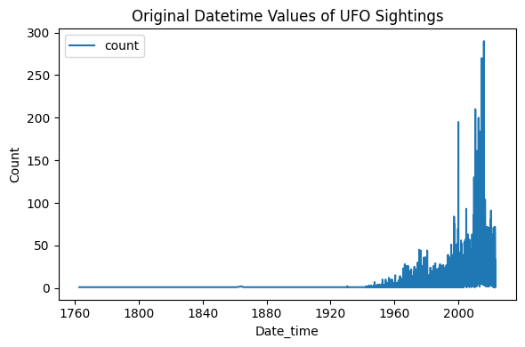

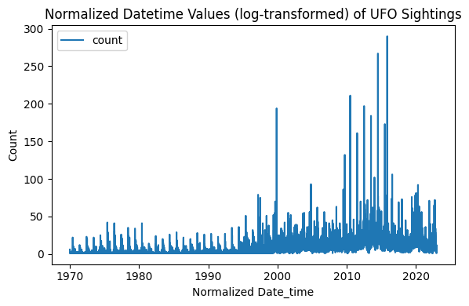

```python
# make line graphs of datetime and normalized datetime (logged transformed) by count
compare_df = ufo_reset_df.copy()

# get the datetime from the index of compare_df
compare_df["date"] = pd.to_datetime(compare_df.index)
# group by date values
untran_datetime = compare_df["date"].groupby(compare_df["date"].dt.date).size()
# sort by count in descending order
untran_datetime = untran_datetime.sort_values(ascending=False)
# reset index to get a dataframe
untran_datetime = untran_datetime.reset_index(name="count")

# reverse the log transformation values and convert the date_time_epoch values to a datetime type for plotting
compare_df["date_log"] = pd.to_datetime(np.exp(compare_df["date_time_log"]), unit="s")
# group by date_log values
log_datetime = compare_df["date_log"].groupby(compare_df["date_log"].dt.date).size()
# sort by count in descending order
log_datetime = log_datetime.sort_values(ascending=False)
# reset index to get a dataframe
log_datetime = log_datetime.reset_index(name="count")

# print the resulting dataframe's total count of rows
print("Total rows of data: ", compare_df.shape[0])

# plot graphs of original datetime and normalized datetime columns
untran_datetime.plot(x="date", xlabel="datetime", y="count", ylabel="count", kind="line", legend=True)
plt.title("Original Datetime Values of UFO Sightings")
plt.xlabel("Date_time")
plt.ylabel("Count")
plt.tight_layout()
plt.show()
# normalized datetime graph
log_datetime.plot(x="date_log", xlabel="datetime", y="count", ylabel="count", kind="line", legend=True)
plt.title("Normalized Datetime Values (log-transformed) of UFO Sightings")
plt.xlabel("Normalized Date_time")
plt.ylabel("Count")
plt.tight_layout()
plt.show()
```

# Normalize duration column using MinMaxScaler

```
Total rows of data:  139674
```

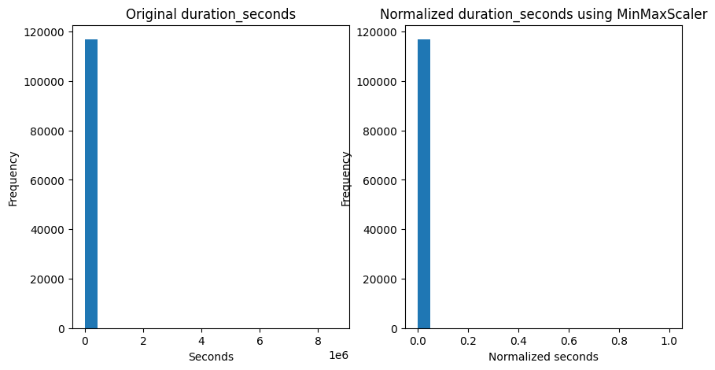

```python
normal_df_dur = ufo_reset_df  # reference the duration_df

# convert the timedelta column, duration, to a numerical column in seconds and store values in a
#   new column called duration_seconds
normal_df_dur["duration_seconds"] = normal_df_dur["duration"].dt.total_seconds()

# create an instance of MinMaxScaler
scaler = MinMaxScaler()

# fit and transform the duration_seconds column and assign values to a new column "duration_normalized"
normal_df_dur["duration_norm"] = scaler.fit_transform(normal_df_dur[["duration_seconds"]])

# print the resulting dataframe's total count of rows
print("Total rows of data: ", normal_df_dur.shape[0])

# plot histograms of original and normalized duration_seconds columns
plt.figure(figsize=(10, 5))
plt.subplot(1, 2, 1)
plt.hist(normal_df_dur["duration_seconds"], bins=20)
plt.title("Original duration_seconds")
plt.xlabel("Seconds")
plt.ylabel("Frequency")

plt.subplot(1, 2, 2)
plt.hist(normal_df_dur["duration_norm"], bins=20)
plt.title("Normalized duration_seconds using MinMaxScaler")
plt.xlabel("Normalized seconds")
plt.ylabel("Frequency")
plt.show()
```

```python
ufo_reset_df.shape[0]
```

```
139674
```

# Graph of Counts by Duration

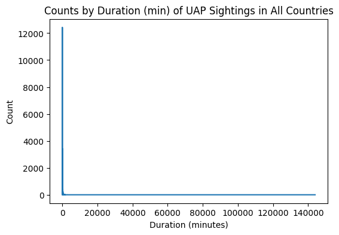

```python
# pt 1
compare_df = ufo_reset_df.copy()  # copy duration_df in case we alter it

# get the time in minutes by accessing total_seconds() and divide by 60
time_min = compare_df["duration"].dt.total_seconds() / 60

# convert the Series to a DataFrame with a column name
time_min = time_min.to_frame(name="duration")

# group by the duration column of the DataFrame
time_min = time_min.groupby("duration").size()

# plot a histogram graph of counts by duration min for all countries
#time_min.plot(x="duration", xlabel="duration min", y="count", ylabel="count", kind="line", label="Counts by Duration (min) of UAP Sightings in All Countries")
time_min.plot(x="duration", y="count", kind="line", figsize=(6,4))
plt.title("Counts by Duration (min) of UAP Sightings in All Countries")
plt.xlabel("Duration (minutes)")
plt.ylabel("Count")
plt.show()
```

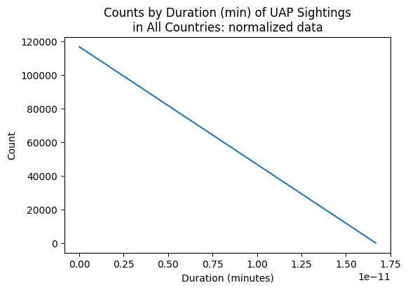

```python
# pt 2
compare_df = normal_df_dur.copy()  # copy normal_df_dur in case we alter it

# convert the duration_normalized column to a timedelta type
compare_df["duration_norm"] = pd.to_timedelta(compare_df["duration_norm"])

# get the time in minutes by accessing total_seconds() and divide by 60
time_min = compare_df["duration_norm"].dt.total_seconds() / 60

# convert the Series to a DataFrame with a column name
time_min = time_min.to_frame(name="duration_norm")

# group by the duration column of the DataFrame
time_min = time_min.groupby("duration_norm").size()

# plot a histogram graph of counts by duration min for all countries
#time_min.plot(x="duration", xlabel="duration min", y="count", ylabel="count", kind="line", label="Counts by Duration (min) of UAP Sightings in All Countries"
time_min.plot(x="duration_norm", y="count", kind="line", figsize=(6,4))
plt.title("Counts by Duration (min) of UAP Sightings\nin All Countries: normalized data")
plt.xlabel("Duration (minutes)")
plt.ylabel("Count")
plt.show()
```

# Part I. Project Goal # 1: What is the frequency of UAP sightings based on year, city, and country?

## 1. Frequency of a sighting over a year, city, and country (selected features chosen by SelectKBest using r_regression):

### Frequency = grouped by year, city, country and counting each group's size

```
Example:
If we have Allentown, PA, we would get frequencies by counting the number of reports of sightings over years between 2009 and 2012.
The dataframe has for year 2009, 3 observations --> freq = 3
                  for year 2010, 1 observation --> freq = 1
                  for year 2011, 1 observation --> freq = 1
                  for year 2012, 8 observations --> freq = 8

UFO Dataframe (Relevant Columns)
  Date_time               Year    City        Country  Frequency
2009-02-15 23:00:00   2009  Allentown    USA     3
2009-03-06 20:45:00   2009  Allentown    USA     3
2009-03-22 23:54:00   2009  Allentown    USA     3
2010-10-02 20:00:00   2010  Allentown    USA     1
2011-10-20 07:30:00   2011  Allentown    USA     1
2012-01-15 23:20:00   2012  Allentown    USA     8
2012-04-05 17:45:00   2012  Allentown    USA     8
2012-06-30 02:30:00   2012  Allentown    USA     8
2012-07-06 22:40:00   2012  Allentown    USA     8
2012-08-25 21:00:00   2012  Allentown    USA     8
2012-10-17 20:45:00   2012  Allentown    USA     8
2012-11-19 15:00:00   2012  Allentown    USA     8
2012-11-21 17:45:00   2012  Allentown    USA     8
```

## 2. Probability and percent probability of sighting by selected features:

### Probability = frequency / sum of all frequencies (freq divided by sum of all freqs)

### Percent prob = prob. multiply by 100

```python
# compute freq, probability, and percent probability and assign them to new
#   columns "freq", "prob", and "percent_prob" for ufo_reset_df

# convert the date_time column to datetime format
ufo_reset_df["date_time"] = pd.to_datetime(ufo_reset_df.index)

# get the year and month from the date_time column
ufo_reset_df["year"] = ufo_reset_df["date_time"].dt.year

# calculate the frequencies of the group columns by selected features
ufo_reset_df["freq"] = ufo_reset_df.groupby(["year","city","country"])["year"].transform("count")

# calculate the probability of a ufo sighting
ufo_reset_df["prob"] = ufo_reset_df["freq"] / (ufo_reset_df["freq"].sum())
sum_freq = ufo_reset_df["freq"].sum()

# calculate the percent probability of a ufo sighting
ufo_reset_df["percent_prob"] = round(ufo_reset_df["prob"]*100,4)
```

# Store sum of all frequencies (sum_freq) for use later in frequency and probabilities calculations

```python
# store sum of all frequencies for use later in the model calculations
sum_freq = ufo_reset_df["freq"].sum()
sum_freq
```

```
656479.0
```

# Graph the UFO sighting frequency distribution

```
** Note: Showing only frequencies last 10 rows for each dataframe

Frequency by Year, City, and Country
  year             city      country  freq  percent_prob
 2022           Tucson          USA    17        0.0026
 2022    Washington Dc          USA     4        0.0006
 2022 Mentor Headlands          USA     1        0.0002
 2022   East Greenwich          USA     2        0.0003
 2022         Franklin          USA    11        0.0017
 2022            Essex       Canada     1        0.0002
 2022         Columbus          USA    20        0.0030
 2022     Johannesburg South Africa     3        0.0005
 2022           Newark          USA     4        0.0006
 2022        Ahmedabad      Unknown     1        0.0002
```

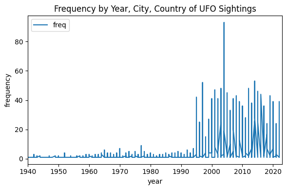

```python
# get different feature groupings and display the frequencies for each group
freq_df = ufo_reset_df[["year","city","country","freq","percent_prob"]]

# convert frequency column data type to int to display as integers
freq_df["freq"] = freq_df["freq"].astype("Int64")
# drop na values from freq_vals
freq_df = freq_df.dropna()

# print the frequencies and title of table
print("** Note: Showing only frequencies last 10 rows for each dataframe")
print("\nFrequency by Year, City, and Country\n", freq_df.tail(10).to_string(index=False))

# make a line graph of frequency by year for UFO sightings
freq_df.plot(x="year", xlabel="year", y="freq", ylabel="frequency", kind="line", legend=True, title="Frequency by Year, City, Country of UFO Sightings")
plt.legend(loc="upper left")
plt.xlim(1940, 2023) # set the xlim to year
plt.tight_layout()
# save as png file
plt.savefig("plots/freq_line.png")
plt.show()
```

# Histogram of frequency values by year, city, and country

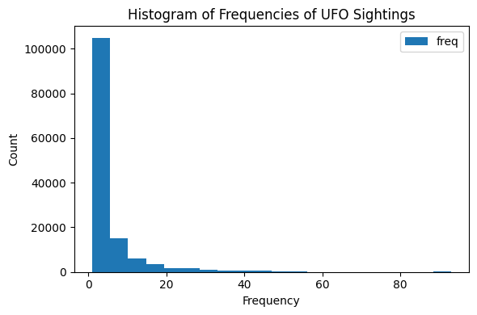

```python
# plot the histogram of frequency values by year, city, and country
# get the freq and year values place in series objects
freq_vals = freq_df[["freq"]]
# drop na values from freq_vals
freq_vals = freq_vals.dropna()

# make a histogram with freq_vals
plt.rcParams["figure.figsize"] = (6, 4)
plt.hist(freq_vals, label="freq", bins=20)

# set title and formatting
plt.title("Histogram of Frequencies of UFO Sightings")
plt.legend(loc="upper right")
plt.xlabel("Frequency")
plt.ylabel("Count")
plt.tight_layout()
# save as png file
plt.savefig("plots/freq_hist.png")
plt.show()
```

# Histogram of percent probabilities values by year, city, and country

```python
# get the count of percent probabilities by year, city, and country
# get the percent_prob and year values place in series objects
freq_vals = freq_df[["freq","percent_prob"]]
# drop na values from freq_vals
#freq_vals = freq_vals.dropna()

# group by percent_prob and count size
freq_vals = freq_vals.groupby(["percent_prob"]).size()
# sort the values in descending order
freq_vals = freq_vals.sort_values(ascending=False)
# reset the index to count to get a dataframe
freq_vals = freq_vals.reset_index(name="count")

# print the frequencies and title of table
print("Percent Probability by Year, City, and Country\n", freq_vals.head(10).to_string(index=False))
```

```
Percent Probability by Year, City, and Country
  percent_prob  count
       0.0002  56022
       0.0003  22336
       0.0005  12423
       0.0006   8144
       0.0008   5925
       0.0009   4350
       0.0011   3675
       0.0012   2880
       0.0014   2250
       0.0015   2050
```

```python
ufo_reset_df.shape[0]
```

```
139674
```

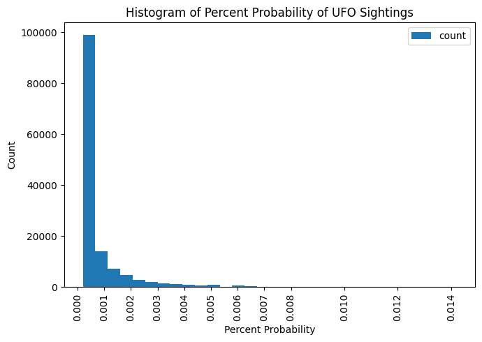

```python
# plot the histogram of percent probabilities by year, city, and country
# get the percent_prob and year values place in series objects
freq_vals = freq_df[["percent_prob"]]

# make a histogram with freq_vals
plt.rcParams["figure.figsize"] = (7, 5)
plt.hist(freq_vals, label="count", bins=30)

# set title and formatting
plt.title("Histogram of Percent Probability of UFO Sightings")
plt.legend(loc="upper right")
plt.xticks([0.000,0.001,0.002,0.003,0.004,0.005,0.006,0.007,0.008,0.010,0.012,0.014], rotation=90)
plt.xlabel("Percent Probability")
plt.ylabel("Count")
plt.tight_layout()
# save as png file
plt.savefig("plots/percent_prob_hist.png")
plt.show()
```

```python
ufo_reset_df.shape[0]
```

```
139674
```

```python
#ufo_reset_df
```

# Project Goal #2: How well are the ML models able to predict the frequency of UFO sightings?

# Feature selection

## Thus, these features will need to be selected for training: city, state, country, shape, duration, year, month

```python
# load data
ufo_data = ufo_reset_df.copy()

# strip the spaces from the column names
ufo_data.columns = ufo_data.columns.str.strip()

# encode categorical features
le = LabelEncoder()

# encode the location features
le.fit(ufo_data["city"])
encoded_city = le.transform(ufo_data["city"])
decoded_city = le.inverse_transform(encoded_city)    # For inversing the LabelEncoder later
ufo_data["city"] = le.transform(ufo_data["city"])

le.fit(ufo_data["state"])
encoded_state = le.transform(ufo_data["state"])
decoded_state = le.inverse_transform(encoded_state)  # For inversing the LabelEncoder
ufo_data["state"] = le.transform(ufo_data["state"])

le.fit(ufo_data["country"])
encoded_ctry = le.transform(ufo_data["country"])
decoded_ctry = le.inverse_transform(encoded_ctry)    # For inversing the LabelEncoder
ufo_data["country"] = le.transform(ufo_data["country"])

# encode the shape feature (in case we use shape as a feature)
le.fit(ufo_data["shape"])
encoded_sh = le.transform(ufo_data["shape"])
decoded_sh = le.inverse_transform(encoded_sh)       # For inversing the LabelEncoder
ufo_data["shape"] = le.transform(ufo_data["shape"])

# get the year and month
ufo_data["year"] = pd.DatetimeIndex(ufo_data.index).year
ufo_data["month"] = pd.DatetimeIndex(ufo_data.index).month

# for duration, it has been normalized already as ufo_reset_df["duration_normalized"]
print("ufo_data[duration_norm]: ", type(ufo_data["duration_norm"].dtypes))
```

```
ufo_data[duration_norm]:  <class 'numpy.dtype[float64]'>
```

```python
# Inversing the LabelEncoder(): display the encoded and decoded location values
print("encoded city = ", encoded_city)
print("decoded city = ", decoded_city)
print("\nencoded state = ", encoded_state)
print("decoded state = ", decoded_state)
print("\nencoded country = ", encoded_ctry)
print("decoded country = ", decoded_ctry)
print("\nencoded shape = ", encoded_sh)
print("decoded shape = ", decoded_sh)
```

```
encoded city =  [11002  3330 13169 ...  9076 13180   144]
decoded city =  ['Lulworth' 'Cherokee' 'New York' ... 'Johannesburg' 'Newark' 'Ahmedabad']

encoded state =  [211 119 136 ...  68  58 209]
decoded state =  [None 'NC' 'NY' ... 'GAUTENG' 'DE' 'nan']

encoded country =  [325 301 301 ... 254 301 308]
decoded country =  [None 'USA' 'USA' ... 'South Africa' 'USA' 'Unknown']

encoded shape =  [23 11  5 ... 21 14 22]
decoded shape =  [nan 'fireball' 'cross' ... 'triangle' 'light' 'unknown']
```

## Feature selection by RandomForestClassifier

# find the best parameters for RandomForestClassifier

# make the features dataframe X

# make the target variable y

# make an instance of rfc

rfc = RandomForestClassifier()

# choose the parameters for the rfc

# make an instance of GridSearchCV

cv = GridSearchCV(rfc,parameters,cv=5)

# fit the training and target set and flatten y array with ravel function

# display() takes the results and displays the results

```python
# use RandomForestClassifier to find highest scoring features

# make the features dataframe X
X = pd.DataFrame(ufo_data[["year","month","city","state","country","shape","duration_norm"]])
X = X.dropna()

# make the target variable y
y = X.groupby(["year","month","city","state","country","shape","duration_norm"])["year"].transform("count")

# create an instance of the classifier
rf = RandomForestClassifier(max_depth=2, n_estimators=5)
# fit the classifier on the dataset
rf.fit(X, y)
# get the feature importances
importances = rf.feature_importances_
# get the feature names
names = rf.feature_names_in_
# sort the features by their importances in descending order
indices = np.argsort(importances)[::-1]

# print the score ranking
print("Score ranking:")

# create list for features to be selected
selected_features =[]

for i in range(X.shape[1]):
    print(i + 1, ". Feature ", indices[i], " ", importances[indices[i]])

    # add name to the selected_features list
    selected_features.append(names[indices[i]])

# get the top 4 features
top_features_names = selected_features[:4]

# Use the selected features to train another model or evaluate the performance
print("\nSelected features: ", top_features_names)
```

```
Score ranking:
1 . Feature  6   0.317312575176565
2 . Feature  3   0.18837437956639272
3 . Feature  4   0.1833374531359424
4 . Feature  0   0.16908440061137714
5 . Feature  2   0.12012141807225152
6 . Feature  5   0.016662546864057593
7 . Feature  1   0.00510722657341364

Selected features:  ['duration_norm', 'state', 'country', 'year']
```

## Feature selection by SelectKBest selector (computing Pearson's r correlation coefficient):

### Results from a GridSearch to find best parameter settings: inconclusive because very small almost identical numbers for both k values and scoring functions

### Decision: choose k = 3 and scoring function = r_regression

```python
# find best parameter settings for SelectKBest selector
from sklearn.model_selection import GridSearchCV
from sklearn.feature_selection import f_classif, chi2, f_regression

# make the features dataframe X
X = pd.DataFrame(ufo_data[["year","month","city","state","country","shape","duration_norm"]])
X = X.dropna()

# make the target variable y
y = X.groupby(["year","month","city","state","country","shape","duration_norm"])["year"].transform("count")
# make an instance of selector
selector = SelectKBest()
# choose the parameters for the rfc
parameters = {
    "k":[2,3,4,5,6,7],
    "score_func":[r_regression, f_classif, chi2, f_regression]
}
# make an instance of GridSearchCV
cv = GridSearchCV(selector, parameters, scoring="neg_mean_squared_error", cv=5)
# fit the training and target set and flatten y array with ravel function
cv.fit(X,y.values.ravel())

# display the results
print("Best parameters are: ", cv.best_params_)
# get rank score
rank_score = cv.cv_results_["rank_test_score"]
# get params that are scored
params = cv.cv_results_["params"]
for score, params in zip(rank_score, params):
    print(round(score, 3)," for the ", params)
```

```
Best parameters are:  {'k': 2, 'score_func': <function r_regression at 0x00000206C30B9670>}
1  for the  {'k': 2, 'score_func': <function r_regression at 0x00000206C30B9670>}
1  for the  {'k': 2, 'score_func': <function f_classif at 0x00000206C30B94C0>}
1  for the  {'k': 2, 'score_func': <function chi2 at 0x00000206C30B95E0>}
1  for the  {'k': 2, 'score_func': <function f_regression at 0x00000206C30B9700>}
1  for the  {'k': 3, 'score_func': <function r_regression at 0x00000206C30B9670>}
1  for the  {'k': 3, 'score_func': <function f_classif at 0x00000206C30B94C0>}
1  for the  {'k': 3, 'score_func': <function chi2 at 0x00000206C30B95E0>}
1  for the  {'k': 3, 'score_func': <function f_regression at 0x00000206C30B9700>}
1  for the  {'k': 4, 'score_func': <function r_regression at 0x00000206C30B9670>}
1  for the  {'k': 4, 'score_func': <function f_classif at 0x00000206C30B94C0>}
1  for the  {'k': 4, 'score_func': <function chi2 at 0x00000206C30B95E0>}
1  for the  {'k': 4, 'score_func': <function f_regression at 0x00000206C30B9700>}
1  for the  {'k': 5, 'score_func': <function r_regression at 0x00000206C30B9670>}
1  for the  {'k': 5, 'score_func': <function f_classif at 0x00000206C30B94C0>}
1  for the  {'k': 5, 'score_func': <function chi2 at 0x00000206C30B95E0>}
1  for the  {'k': 5, 'score_func': <function f_regression at 0x00000206C30B9700>}
1  for the  {'k': 6, 'score_func': <function r_regression at 0x00000206C30B9670>}
1  for the  {'k': 6, 'score_func': <function f_classif at 0x00000206C30B94C0>}
1  for the  {'k': 6, 'score_func': <function chi2 at 0x00000206C30B95E0>}
1  for the  {'k': 6, 'score_func': <function f_regression at 0x00000206C30B9700>}
1  for the  {'k': 7, 'score_func': <function r_regression at 0x00000206C30B9670>}
1  for the  {'k': 7, 'score_func': <function f_classif at 0x00000206C30B94C0>}
1  for the  {'k': 7, 'score_func': <function chi2 at 0x00000206C30B95E0>}
1  for the  {'k': 7, 'score_func': <function f_regression at 0x00000206C30B9700>}
```

```python
# Use the same X features and y target that we did for RandomForestClassifier
# make the features dataframe X
X = pd.DataFrame(ufo_data[["year","month","city","state","country","shape","duration_norm"]])
X = X.dropna()

# make the target variable y
y = X.groupby(["year","month","city","state","country","shape","duration_norm"])["year"].transform("count")

# split the data into train and test sets
X_train, X_test, y_train, y_test = train_test_split(X, y, test_size=0.2, random_state=42)

# make an instance of the selector with r_regression as the scoring function and k=3
selector = SelectKBest(r_regression, k=3)

# fit the selector on the training data
selector.fit(X_train, y_train)

# get the scores of the features
scores = selector.scores_
print("Scores:", scores)

# get the selected features
selected_features = X.columns[selector.get_support()]
print("\nSelected features:", selected_features)
```

```
Scores: [ 0.01371672  0.00046502  0.01140011 -0.01914446  0.0161268   0.00182053
 -0.00187334]

Selected features: Index(['year', 'city', 'country'], dtype='object')
```